# BDA 507 Introduction to Computer Programming (Python) Project

## Mustafa Ömer Güçlü

### 0. Import Required Packages

```python
import pandas as pd
import numpy as np
import matplotlib.pyplot as plt
import datetime
from sklearn import datasets, linear_model
from sklearn.linear_model import LinearRegression
import statsmodels.api as sm
from sklearn.model_selection import train_test_split
from sklearn.preprocessing import StandardScaler
from sklearn.linear_model import LinearRegression
from sklearn.metrics import r2_score
import seaborn as sns
%matplotlib inline
from scipy import stats
```

### 1. Data Import & Wrangling

#### 1.1. Data Import

- I use a kaggle dataset of youtube trends linked below.
- After getting all data set I choose USvideos.csv to explore you can use link below
- [Data Link](https://drive.google.com/file/d/1BsCJqu0xzllIxFptzKUHPReJ34xB5897/view?usp=sharing)
- After data download to your working directory: Let's start our journey

```python
US_df = pd.read_csv ('USvideos.csv')
type(US_df) # Data in csv format general dataframe preperad by reading given directory cahnge directory to your file path
```

```
pandas.core.frame.DataFrame
```

#### 1.2. General Data Exploration

```python
US_df.dtypes # general look for colomn data types
```

```
video_id                  object
trending_date             object
title                     object
channel_title             object
category_id                int64
publish_time              object
tags                      object
views                      int64
likes                      int64
dislikes                   int64
comment_count              int64
thumbnail_link            object
comments_disabled           bool
ratings_disabled            bool
video_error_or_removed      bool
description               object
dtype: object
```

#### 1.2. Publish Time Convertion from String to Date

```python
US_df["publish_time"].describe()# general look publish time column
```

```
count                        40949
unique                        6269
top       2018-05-18T14:00:04.000Z
freq                            50
Name: publish_time, dtype: object
```

```python
US_df["publish_time"] = US_df["publish_time"].map(lambda x: datetime.datetime.strptime(x, '%Y-%m-%dT%H:%M:%S.%fZ')) # change data type of publish time from string to date time
US_df["publish_time"].head()
```

```
0   2017-11-13 17:13:01
1   2017-11-13 07:30:00
2   2017-11-12 19:05:24
3   2017-11-13 11:00:04
4   2017-11-12 18:01:41
Name: publish_time, dtype: datetime64[ns]
```

```python
US_df["publish_time"].tail()
```

```
40944   2018-05-18 13:00:04
40945   2018-05-18 01:00:06
40946   2018-05-18 17:34:22
40947   2018-05-17 17:00:04
40948   2018-05-17 17:09:38
Name: publish_time, dtype: datetime64[ns]
```

#### 1.3. Trending Date Convertion from String to Date

```python
US_df["trending_date"].describe()# general look trending date column
```

```
count        40949
unique         205
top       17.01.12
freq           200
Name: trending_date, dtype: object
```

```python
US_df["trending_date"].head()
```

```
0    17.14.11
1    17.14.11
2    17.14.11
3    17.14.11
4    17.14.11
Name: trending_date, dtype: object
```

```python
US_df["trending_date"] = US_df["trending_date"].map(lambda x: datetime.datetime.strptime(x,'%y.%d.%m')) # change data type of trending date from string to date type
US_df["trending_date"].head()
```

```
0   2017-11-14
1   2017-11-14
2   2017-11-14
3   2017-11-14
4   2017-11-14
Name: trending_date, dtype: datetime64[ns]
```

#### 1.4. Getting Data Quality < Number of Unique Values & Null Values & Overall Counts & Duplicate>

```python
US_df.nunique()
```

```
video_id                   6351
trending_date               205
title                      6455
channel_title              2207
category_id                  16
publish_time               6269
tags                       6055
views                     40478
likes                     29850
dislikes                   8516
comment_count             13773
thumbnail_link             6352
comments_disabled             2
ratings_disabled              2
video_error_or_removed        2
description                6901
dtype: int64
```

```python
US_df.isnull().sum()
```

```
video_id                    0
trending_date               0
title                       0
channel_title               0
category_id                 0
publish_time                0
tags                        0
views                       0
likes                       0
dislikes                    0
comment_count               0
thumbnail_link              0
comments_disabled           0
ratings_disabled            0
video_error_or_removed      0
description               570
dtype: int64
```

```python
US_df.count()
```

```
video_id                  40949
trending_date             40949
title                     40949
channel_title             40949
category_id               40949
publish_time              40949
tags                      40949
views                     40949
likes                     40949
dislikes                  40949
comment_count             40949
thumbnail_link            40949
comments_disabled         40949
ratings_disabled          40949
video_error_or_removed    40949
description               40379
dtype: int64
```

```python
US_df_video_id2 = US_df[["video_id","trending_date"]]
US_df_video_id2.head()
```

|  | video_id | trending_date |
| --- | --- | --- |
| 0 | 2kyS6SvSYSE | 2017-11-14 |
| 1 | 1ZAPwfrtAFY | 2017-11-14 |
| 2 | 5qpjK5DgCt4 | 2017-11-14 |
| 3 | puqaWrEC7tY | 2017-11-14 |
| 4 | d380meD0W0M | 2017-11-14 |

- Data should be singular by video_id, publish_time and trending_date

```python
US_df[["video_id","trending_date",'publish_time','views']].groupby(["video_id",'publish_time',"trending_date"]).count().sort_values(by='views',ascending=False).head() # Check duplicate data views just used for count you can change any other column header
```

| video_id | publish_time | trending_date | views |
| --- | --- | --- | --- |
| Dwc27Lsr1EY | 2018-05-13 16:29:55 | 2018-05-15 | 2 |
| WF82ABLw8s4 | 2018-05-14 02:23:01 | 2018-05-15 | 2 |
| mdWcaWBxxcY | 2018-05-11 09:23:16 | 2018-05-15 | 2 |
| jzLlsbdrwQk | 2018-05-13 15:00:57 | 2018-05-15 | 2 |
| 2PH7dK6SLC8 | 2018-05-10 17:00:01 | 2018-05-15 | 2 |

```python
US_df[(US_df['video_id']=='Dwc27Lsr1EY')&(US_df['trending_date']=='2018-05-15')] # a close look a duplicated rows of same video ID
```

|  | video_id | trending_date | title | channel_title | category_id | publish_time | tags | views | likes | dislikes | comment_count | thumbnail_link | comments_disabled | ratings_disabled | video_error_or_removed | description |
| --- | --- | --- | --- | --- | --- | --- | --- | --- | --- | --- | --- | --- | --- | --- | --- | --- |
| 34772 | Dwc27Lsr1EY | 2018-05-15 | MANIFEST \| Official Trailer \| NBC Fall Shows 2018 | Manifest | 24 | 2018-05-13 16:29:55 | NBC\|"2018"\|"New Show"\|"trailer"\|"promo"\|"plane... | 2061448 | 5290 | 1861 | 546 | https://i.ytimg.com/vi/Dwc27Lsr1EY/default.jpg | False | False | False | In 2013, Flight 828 disappeared into thin air.... |
| 34921 | Dwc27Lsr1EY | 2018-05-15 | MANIFEST \| Official Trailer \| NBC Fall Shows 2018 | Manifest | 24 | 2018-05-13 16:29:55 | NBC\|"2018"\|"New Show"\|"trailer"\|"promo"\|"plane... | 2061448 | 5290 | 1861 | 546 | https://i.ytimg.com/vi/Dwc27Lsr1EY/default.jpg | False | False | False | In 2013, Flight 828 disappeared into thin air.... |

```python
US_df.count() # count of values before duplicate removal
```

```
video_id                  40949
trending_date             40949
title                     40949
channel_title             40949
category_id               40949
publish_time              40949
tags                      40949
views                     40949
likes                     40949
dislikes                  40949
comment_count             40949
thumbnail_link            40949
comments_disabled         40949
ratings_disabled          40949
video_error_or_removed    40949
description               40379
dtype: int64
```

```python
US_df.drop_duplicates().count() # count of values after duplicate removal
```

```
video_id                  40901
trending_date             40901
title                     40901
channel_title             40901
category_id               40901
publish_time              40901
tags                      40901
views                     40901
likes                     40901
dislikes                  40901
comment_count             40901
thumbnail_link            40901
comments_disabled         40901
ratings_disabled          40901
video_error_or_removed    40901
description               40332
dtype: int64
```

```python
US_df.drop_duplicates()[["video_id","trending_date",'views']].groupby(["video_id","trending_date"]).count().sort_values(by='views',ascending=False)
```

| video_id | trending_date | views |
| --- | --- | --- |
| YI3tsmFsrOg | 2018-05-15 | 2 |
| vY_5EvoL1Is | 2018-05-15 | 2 |
| -0CMnp02rNY | 2018-06-06 | 1 |
| exsOim0Lyl4 | 2018-02-03 | 1 |
| exjMt3v81tA | 2018-04-24 | 1 |
| ... | ... | ... |
| KRc50VFUsTk | 2018-06-13 | 1 |
|  | 2018-06-14 | 1 |
| KU-v13ib_1U | 2018-02-05 | 1 |
|  | 2018-02-06 | 1 |
| zzQsGL_F9_c | 2018-02-06 | 1 |

40899 rows × 1 columns

- There are two video id's having multiple rows after dropping duplicates. They may be poor data

```python
US_df = US_df[(US_df['video_id']!='YI3tsmFsrOg')|(US_df['trending_date']!='2018-05-15')] #remove poor data that  duplicate removal cannot remove
US_df = US_df[(US_df['video_id']!='vY_5EvoL1Is')|(US_df['trending_date']!='2018-05-15')] #remove poor data that  duplicate removal cannot remove
```

```python
US_df.drop_duplicates(inplace=True)
```

```python
US_df[["video_id","trending_date",'views']].groupby(["video_id","trending_date"]).count().sort_values(by='views',ascending=False)
```

| video_id | trending_date | views |
| --- | --- | --- |
| -0CMnp02rNY | 2018-06-06 | 1 |
| exsOim0Lyl4 | 2018-02-02 | 1 |
| exjMt3v81tA | 2018-04-15 | 1 |
|  | 2018-04-24 | 1 |
|  | 2018-04-25 | 1 |
| ... | ... | ... |
| KRc50VFUsTk | 2018-06-13 | 1 |
|  | 2018-06-14 | 1 |
| KU-v13ib_1U | 2018-02-05 | 1 |
|  | 2018-02-06 | 1 |
| zzQsGL_F9_c | 2018-02-06 | 1 |

40897 rows × 1 columns

```python
US_df.count() # count of values after real duplicate removal
```

```
video_id                  40897
trending_date             40897
title                     40897
channel_title             40897
category_id               40897
publish_time              40897
tags                      40897
views                     40897
likes                     40897
dislikes                  40897
comment_count             40897
thumbnail_link            40897
comments_disabled         40897
ratings_disabled          40897
video_error_or_removed    40897
description               40328
dtype: int64
```

### 2. Data Analyses, Descriptive Statistics and Visualization

#### 2.1. Data Types

```python
US_df.dtypes
```

```
video_id                          object
trending_date             datetime64[ns]
title                             object
channel_title                     object
category_id                        int64
publish_time              datetime64[ns]
tags                              object
views                              int64
likes                              int64
dislikes                           int64
comment_count                      int64
thumbnail_link                    object
comments_disabled                   bool
ratings_disabled                    bool
video_error_or_removed              bool
description                       object
dtype: object
```

#### 2.2 Descriptive Statistics

- Descriptive Statistics of Numeric Columns

```python
US_df.describe(percentiles=[.01,.1,.25,.5,.75,.90,.99]).round(0) # general descriptive look for integer data columns
```

|  | category_id | views | likes | dislikes | comment_count |
| --- | --- | --- | --- | --- | --- |
| count | 40897.0 | 40897.0 | 40897.0 | 40897.0 | 40897.0 |
| mean | 20.0 | 2360620.0 | 74269.0 | 3712.0 | 8448.0 |
| std | 8.0 | 7398077.0 | 229009.0 | 29048.0 | 37453.0 |
| min | 1.0 | 549.0 | 0.0 | 0.0 | 0.0 |
| 1% | 1.0 | 4205.0 | 15.0 | 1.0 | 0.0 |
| 10% | 10.0 | 70531.0 | 1116.0 | 58.0 | 159.0 |
| 25% | 17.0 | 241967.0 | 5417.0 | 202.0 | 613.0 |
| 50% | 24.0 | 680971.0 | 18069.0 | 630.0 | 1855.0 |
| 75% | 25.0 | 1820947.0 | 55326.0 | 1936.0 | 5751.0 |
| 90% | 27.0 | 4601203.0 | 160164.0 | 6031.0 | 16939.0 |
| 99% | 28.0 | 29922190.0 | 923702.0 | 43663.0 | 100733.0 |
| max | 43.0 | 225211923.0 | 5613827.0 | 1674420.0 | 1361580.0 |

- Value Counts of Categorical Columns

```python
USlist = list(US_df.select_dtypes(include=['object']).columns) # a list for close look string type data in the dataframe
```

```python
US_df[USlist] # a close look string type data in the dataframe
```

|  | video_id | title | channel_title | tags | thumbnail_link | description |
| --- | --- | --- | --- | --- | --- | --- |
| 0 | 2kyS6SvSYSE | WE WANT TO TALK ABOUT OUR MARRIAGE | CaseyNeistat | SHANtell martin | https://i.ytimg.com/vi/2kyS6SvSYSE/default.jpg | SHANTELL'S CHANNEL - https://www.youtube.com/s... |
| 1 | 1ZAPwfrtAFY | The Trump Presidency: Last Week Tonight with J... | LastWeekTonight | last week tonight trump presidency\|"last week ... | https://i.ytimg.com/vi/1ZAPwfrtAFY/default.jpg | One year after the presidential election, John... |
| 2 | 5qpjK5DgCt4 | Racist Superman \| Rudy Mancuso, King Bach & Le... | Rudy Mancuso | racist superman\|"rudy"\|"mancuso"\|"king"\|"bach"... | https://i.ytimg.com/vi/5qpjK5DgCt4/default.jpg | WATCH MY PREVIOUS VIDEO ▶ \n\nSUBSCRIBE ► http... |
| 3 | puqaWrEC7tY | Nickelback Lyrics: Real or Fake? | Good Mythical Morning | rhett and link\|"gmm"\|"good mythical morning"\|"... | https://i.ytimg.com/vi/puqaWrEC7tY/default.jpg | Today we find out if Link is a Nickelback amat... |
| 4 | d380meD0W0M | I Dare You: GOING BALD!? | nigahiga | ryan\|"higa"\|"higatv"\|"nigahiga"\|"i dare you"\|"... | https://i.ytimg.com/vi/d380meD0W0M/default.jpg | I know it's been a while since we did this sho... |
| ... | ... | ... | ... | ... | ... | ... |
| 40944 | BZt0qjTWNhw | The Cat Who Caught the Laser | AaronsAnimals | aarons animals\|"aarons"\|"animals"\|"cat"\|"cats"... | https://i.ytimg.com/vi/BZt0qjTWNhw/default.jpg | The Cat Who Caught the Laser - Aaron's Animals |
| 40945 | 1h7KV2sjUWY | True Facts : Ant Mutualism | zefrank1 | [none] | https://i.ytimg.com/vi/1h7KV2sjUWY/default.jpg | NaN |
| 40946 | D6Oy4LfoqsU | I GAVE SAFIYA NYGAARD A PERFECT HAIR MAKEOVER ... | Brad Mondo | I gave safiya nygaard a perfect hair makeover ... | https://i.ytimg.com/vi/D6Oy4LfoqsU/default.jpg | I had so much fun transforming Safiyas hair in... |
| 40947 | oV0zkMe1K8s | How Black Panther Should Have Ended | How It Should Have Ended | Black Panther\|"HISHE"\|"Marvel"\|"Infinity War"\|... | https://i.ytimg.com/vi/oV0zkMe1K8s/default.jpg | How Black Panther Should Have EndedWatch More ... |
| 40948 | ooyjaVdt-jA | Official Call of Duty®: Black Ops 4 — Multipla... | Call of Duty | call of duty\|"cod"\|"activision"\|"Black Ops 4" | https://i.ytimg.com/vi/ooyjaVdt-jA/default.jpg | Call of Duty: Black Ops 4 Multiplayer raises t... |

40897 rows × 6 columns

```python
for i in USlist :
    print("\n" ,"<<<",i," >>>" ,"\n" ,"\n" , pd.DataFrame(US_df[i].value_counts()) ) # a very close look string type data in the dataframe
```

```
 <<< video_id  >>>

              video_id
j4KvrAUjn6c        29
8h--kFui1JA        29
iILJvqrAQ_w        28
ulNswX3If6U        28
r-3iathMo7o        28
...               ...
08nkwgZIE4I         1
391JeKrI30w         1
vaIN1OLd6kQ         1
_C14eXiZQWo         1
IEqj7xR9iOU         1

[6351 rows x 1 columns]

 <<< title  >>>

                                                     title
Mission: Impossible - Fallout (2018) - Official...     29
Sam Smith - Pray (Official Video) ft. Logic            29
WE MADE OUR MOM CRY...HER DREAM CAME TRUE!             29
Charlie Puth - BOY [Official Audio]                    28
The ULTIMATE $30,000 Gaming PC Setup                   28
...                                                   ...
What's In Jeanine Amapola's Bag | Spill It | Re...      1
Grace and Frankie - Season 4 | Official Trailer...      1
This Rare Stick Insect Is Among the Last of Its...      1
Instant classic: Relive UMBC’s incredible win o...      1
Cypress FX3 as a Possible Logic Analyzer                1

[6455 rows x 1 columns]

 <<< channel_title  >>>

                                         channel_title
ESPN                                              202
The Tonight Show Starring Jimmy Fallon            197
Netflix                                           193
```

[output cut: 46 more lines]

```

                                                     description
► Listen LIVE: http://power1051fm.com/\n► Faceb...           58
Jukin Media Verified (Original) * For licensing...           46
My Twitter: https://twitter.com/prozdkp\nMy Let...           38
thank you for watching this video please like a...           29
The first round’s over, are you ready for the s...           28
...                                                         ...
Check out what British soldiers ate during The ...            1
Ashley Graham, Adwoa Aboah, Imaan Hammam, Raque...            1
Ahead of Tuesday's special election in Alabama,...            1
In these turbulent times, James and Kristen Wii...            1
The 2018 Bugatti Chiron has arrived in Forza Mo...            1

[6901 rows x 1 columns]
```

#### 2.3 Data Analysis by Dates

##### 2.3.1. Trend Date vs Views

```python
US_df['trending_year'] = pd.DatetimeIndex(US_df['trending_date']).year
US_df['trending_month'] = pd.DatetimeIndex(US_df['trending_date']).month
US_df['trending_year_month']=US_df['trending_year']*100+US_df['trending_month']
US_df.sort_values("views",ascending= False).head()
```

|  | video_id | trending_date | title | channel_title | category_id | publish_time | tags | views | likes | dislikes | comment_count | thumbnail_link | comments_disabled | ratings_disabled | video_error_or_removed | description | trending_year | trending_month | trending_year_month |
| --- | --- | --- | --- | --- | --- | --- | --- | --- | --- | --- | --- | --- | --- | --- | --- | --- | --- | --- | --- |
| 38547 | VYOjWnS4cMY | 2018-06-02 | Childish Gambino - This Is America (Official V... | ChildishGambinoVEVO | 10 | 2018-05-06 04:00:07 | Childish Gambino\|"Rap"\|"This Is America"\|"mcDJ... | 225211923 | 5023450 | 343541 | 517232 | https://i.ytimg.com/vi/VYOjWnS4cMY/default.jpg | False | False | False | “This is America” by Childish Gambino http://s... | 2018 | 6 | 201806 |
| 38345 | VYOjWnS4cMY | 2018-06-01 | Childish Gambino - This Is America (Official V... | ChildishGambinoVEVO | 10 | 2018-05-06 04:00:07 | Childish Gambino\|"Rap"\|"This Is America"\|"mcDJ... | 220490543 | 4962403 | 338105 | 512337 | https://i.ytimg.com/vi/VYOjWnS4cMY/default.jpg | False | False | False | “This is America” by Childish Gambino http://s... | 2018 | 6 | 201806 |
| 38146 | VYOjWnS4cMY | 2018-05-31 | Childish Gambino - This Is America (Official V... | ChildishGambinoVEVO | 10 | 2018-05-06 04:00:07 | Childish Gambino\|"Rap"\|"This Is America"\|"mcDJ... | 217750076 | 4934188 | 335462 | 509799 | https://i.ytimg.com/vi/VYOjWnS4cMY/default.jpg | False | False | False | “This is America” by Childish Gambino http://s... | 2018 | 5 | 201805 |
| 37935 | VYOjWnS4cMY | 2018-05-30 | Childish Gambino - This Is America (Official V... | ChildishGambinoVEVO | 10 | 2018-05-06 04:00:07 | Childish Gambino\|"Rap"\|"This Is America"\|"mcDJ... | 210338856 | 4836448 | 326902 | 501722 | https://i.ytimg.com/vi/VYOjWnS4cMY/default.jpg | False | False | False | “This is America” by Childish Gambino http://s... | 2018 | 5 | 201805 |
| 37730 | VYOjWnS4cMY | 2018-05-29 | Childish Gambino - This Is America (Official V... | ChildishGambinoVEVO | 10 | 2018-05-06 04:00:07 | Childish Gambino\|"Rap"\|"This Is America"\|"mcDJ... | 205643016 | 4776680 | 321493 | 496211 | https://i.ytimg.com/vi/VYOjWnS4cMY/default.jpg | False | False | False | “This is America” by Childish Gambino http://s... | 2018 | 5 | 201805 |

```python
US_df_trending_yearmonth_agg = US_df.groupby('trending_year_month').agg({'views': ['count','sum', np.mean]}).round()
US_df_trending_yearmonth_agg.columns = ['count','view_sum','view_avg']
```

```python
US_df_trending_yearmonth_agg
```

| trending_year_month | count | view_sum | view_avg |
| --- | --- | --- | --- |
| 201711 | 3400 | 4206798140 | 1237294.0 |
| 201712 | 6200 | 8237204070 | 1328581.0 |
| 201801 | 5796 | 6441668933 | 1111399.0 |
| 201802 | 5571 | 8046104893 | 1444284.0 |
| 201803 | 6183 | 11548564376 | 1867793.0 |
| 201804 | 4800 | 14590073499 | 3039599.0 |
| 201805 | 6147 | 29051595735 | 4726142.0 |
| 201806 | 2800 | 14420249655 | 5150089.0 |

```python
US_df_trending_yearmonth_agg["yearmonth"]=US_df_trending_yearmonth_agg.index
```

```python
US_df_trending_yearmonth_agg["yearmonth"]=US_df_trending_yearmonth_agg["yearmonth"].astype(str)
```

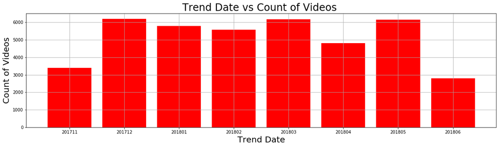

```python
plt.figure(figsize=(20,5))
plt.grid(color='darkgrey', linestyle='-', linewidth=0.8)
plt.bar(US_df_trending_yearmonth_agg['yearmonth'],US_df_trending_yearmonth_agg['count'],color="red")
plt.ticklabel_format(axis='y',style='sci',scilimits=(0,30))
plt.ylabel("Count of Videos", size=20)
plt.xlabel("Trend Date", size=20)
plt.title("Trend Date vs Count of Videos ",size=24)
plt.show()
```

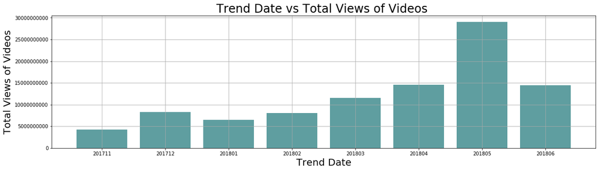

```python
plt.figure(figsize=(20,5))
plt.bar(US_df_trending_yearmonth_agg['yearmonth'],US_df_trending_yearmonth_agg['view_sum'],color="cadetblue")
plt.ticklabel_format(axis='y',style='sci',scilimits=(0,30))
plt.grid(color='darkgrey', linestyle='-', linewidth=0.8)
plt.ylabel("Total Views of Videos", size=20)
plt.xlabel("Trend Date", size=20)
plt.title("Trend Date vs Total Views of Videos ",size=24)
plt.show()
```

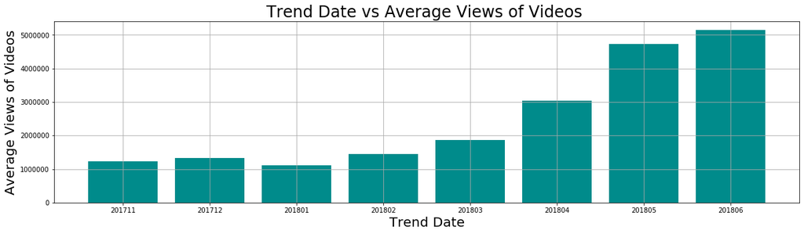

```python
plt.figure(figsize=(20,5))
plt.bar(US_df_trending_yearmonth_agg['yearmonth'],US_df_trending_yearmonth_agg['view_avg'],color="darkcyan")
plt.ticklabel_format(axis='y',style='sci',scilimits=(0,30))
plt.grid(color='darkgrey', linestyle='-', linewidth=0.8)
plt.ylabel("Average Views of Videos", size=20)
plt.xlabel("Trend Date", size=20)
plt.title("Trend Date vs Average Views of Videos ",size=24)
plt.show()
```

#### 2.3.2. Publish Time vs Views

```python
US_df['publish_year'] = pd.DatetimeIndex(US_df['publish_time']).year
US_df['publish_month'] = pd.DatetimeIndex(US_df['publish_time']).month
US_df['publish_year_month']=US_df['publish_year']*100+US_df['publish_month']
US_df.sort_values("views",ascending= False).head()
```

|  | video_id | trending_date | title | channel_title | category_id | publish_time | tags | views | likes | dislikes | ... | comments_disabled | ratings_disabled | video_error_or_removed | description | trending_year | trending_month | trending_year_month | publish_year | publish_month | publish_year_month |
| --- | --- | --- | --- | --- | --- | --- | --- | --- | --- | --- | --- | --- | --- | --- | --- | --- | --- | --- | --- | --- | --- |
| 38547 | VYOjWnS4cMY | 2018-06-02 | Childish Gambino - This Is America (Official V... | ChildishGambinoVEVO | 10 | 2018-05-06 04:00:07 | Childish Gambino\|"Rap"\|"This Is America"\|"mcDJ... | 225211923 | 5023450 | 343541 | ... | False | False | False | “This is America” by Childish Gambino http://s... | 2018 | 6 | 201806 | 2018 | 5 | 201805 |
| 38345 | VYOjWnS4cMY | 2018-06-01 | Childish Gambino - This Is America (Official V... | ChildishGambinoVEVO | 10 | 2018-05-06 04:00:07 | Childish Gambino\|"Rap"\|"This Is America"\|"mcDJ... | 220490543 | 4962403 | 338105 | ... | False | False | False | “This is America” by Childish Gambino http://s... | 2018 | 6 | 201806 | 2018 | 5 | 201805 |
| 38146 | VYOjWnS4cMY | 2018-05-31 | Childish Gambino - This Is America (Official V... | ChildishGambinoVEVO | 10 | 2018-05-06 04:00:07 | Childish Gambino\|"Rap"\|"This Is America"\|"mcDJ... | 217750076 | 4934188 | 335462 | ... | False | False | False | “This is America” by Childish Gambino http://s... | 2018 | 5 | 201805 | 2018 | 5 | 201805 |
| 37935 | VYOjWnS4cMY | 2018-05-30 | Childish Gambino - This Is America (Official V... | ChildishGambinoVEVO | 10 | 2018-05-06 04:00:07 | Childish Gambino\|"Rap"\|"This Is America"\|"mcDJ... | 210338856 | 4836448 | 326902 | ... | False | False | False | “This is America” by Childish Gambino http://s... | 2018 | 5 | 201805 | 2018 | 5 | 201805 |
| 37730 | VYOjWnS4cMY | 2018-05-29 | Childish Gambino - This Is America (Official V... | ChildishGambinoVEVO | 10 | 2018-05-06 04:00:07 | Childish Gambino\|"Rap"\|"This Is America"\|"mcDJ... | 205643016 | 4776680 | 321493 | ... | False | False | False | “This is America” by Childish Gambino http://s... | 2018 | 5 | 201805 | 2018 | 5 | 201805 |

5 rows × 22 columns

```python
US_df_publish_yearmonth_agg = US_df.groupby('publish_year_month').agg({'views': ['count','sum', np.mean]}).round()
US_df_publish_yearmonth_agg.columns = ['count','view_sum','view_avg']
```

```python
US_df_publish_yearmonth_agg
```

| publish_year_month | count | view_sum | view_avg |
| --- | --- | --- | --- |
| 200607 | 1 | 258506 | 258506.0 |
| 200804 | 4 | 200257 | 50064.0 |
| 200806 | 4 | 347321 | 86830.0 |
| 200808 | 3 | 80022 | 26674.0 |
| 200903 | 2 | 30858 | 15429.0 |
| ... | ... | ... | ... |
| 201802 | 6196 | 8981292125 | 1449531.0 |
| 201803 | 6135 | 12899631410 | 2102629.0 |
| 201804 | 5077 | 19827577093 | 3905373.0 |
| 201805 | 6583 | 32417076904 | 4924362.0 |
| 201806 | 744 | 2579516759 | 3467092.0 |

63 rows × 3 columns

```python
US_df_publish_yearmonth_agg["yearmonth"]=US_df_publish_yearmonth_agg.index
```

```python
US_df_publish_yearmonth_agg["yearmonth"]=US_df_publish_yearmonth_agg["yearmonth"].astype(str)
```

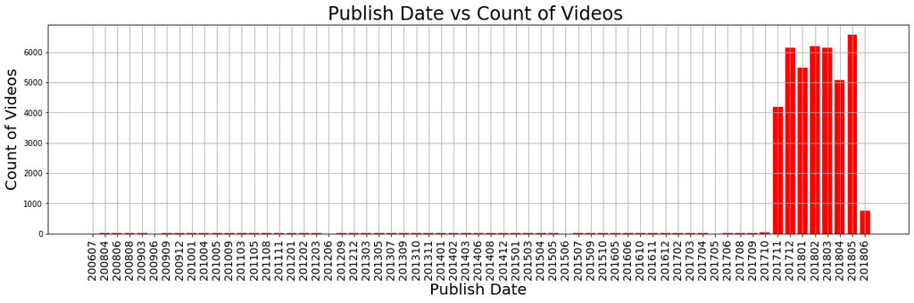

```python
plt.figure(figsize=(20,5))
plt.grid(color='darkgrey', linestyle='-', linewidth=0.8)
plt.bar(US_df_publish_yearmonth_agg['yearmonth'],US_df_publish_yearmonth_agg['count'],color="red")
plt.ticklabel_format(axis='y',style='sci',scilimits=(0,30))
plt.xticks(rotation=90,fontsize=14)
plt.ylabel("Count of Videos", size=20)
plt.xlabel("Publish Date", size=20)
plt.title("Publish Date vs Count of Videos ",size=24)
plt.show()
```

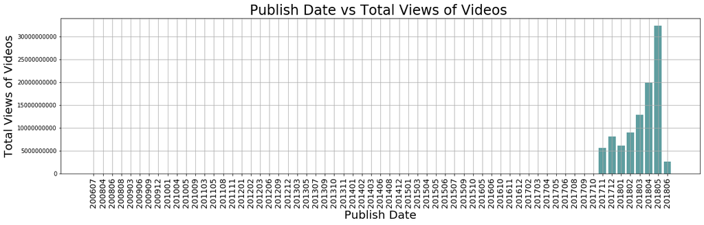

```python
plt.figure(figsize=(20,5))
plt.grid(color='darkgrey', linestyle='-',linewidth=0.8)
plt.bar(US_df_publish_yearmonth_agg['yearmonth'],US_df_publish_yearmonth_agg['view_sum'],color="cadetblue")
plt.ticklabel_format(axis='y',style='sci',scilimits=(0,30))
plt.xticks(rotation=90,fontsize=14)
plt.ylabel("Total Views of Videos", size=20)
plt.xlabel("Publish Date", size=20)
plt.title("Publish Date vs Total Views of Videos ",size=24)
plt.show()
```

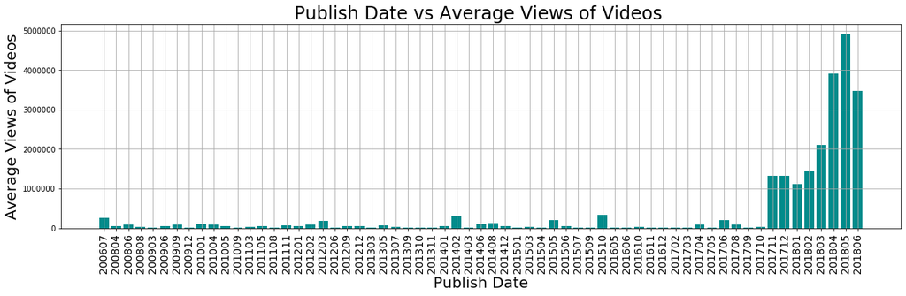

```python
plt.figure(figsize=(20,5))
plt.grid(color='darkgrey', linestyle='-', linewidth=0.8)
plt.bar(US_df_publish_yearmonth_agg['yearmonth'],US_df_publish_yearmonth_agg['view_avg'],color="darkcyan")
plt.ticklabel_format(axis='y',style='sci',scilimits=(0,30))
plt.xticks(rotation=90,fontsize=14)
plt.ylabel("Average Views of Videos", size=20)
plt.xlabel("Publish Date", size=20)
plt.title("Publish Date vs Average Views of Videos ",size=24)
plt.show()
```

### 3 Inferential Statistics

##### 3.1 Channel Title vs Views, Likes and Dislikes

```python
US_df['channel_title'].unique()
US_df['channel_title'].value_counts()
```

```
ESPN                                      202
The Tonight Show Starring Jimmy Fallon    197
Netflix                                   193
TheEllenShow                              192
Vox                                       192
                                         ...
Talks at Google                             1
Brothers Green Eats                         1
JanPaul123                                  1
Missguided                                  1
Katy Perry                                  1
Name: channel_title, Length: 2207, dtype: int64
```

```python
pd.DataFrame(US_df['channel_title'].value_counts()).describe(percentiles=[.01,.1,.25,.5,.75,.90,.99])
```

|  | channel_title |
| --- | --- |
| count | 2207.000000 |
| mean | 18.530585 |
| std | 28.177134 |
| min | 1.000000 |
| 1% | 1.000000 |
| 10% | 2.000000 |
| 25% | 4.000000 |
| 50% | 8.000000 |
| 75% | 19.000000 |
| 90% | 47.000000 |
| 99% | 150.940000 |
| max | 202.000000 |

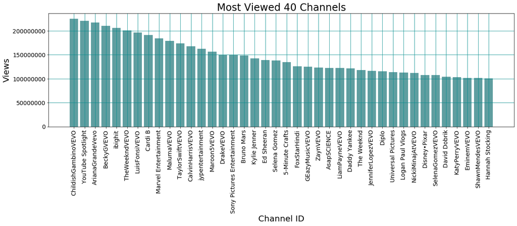

```python
US_df_views_sorted=US_df.sort_values("views",ascending= False)
plt.figure(figsize=(20,5))
#plt.plot(US_df_views_sorted['channel_title'].unique()[0:99],US_df_views_sorted['views'][0:99],color="red",marker="X",markersize=15)
#plt.scatter( US_df_views_sorted['views'][0:99],US_df_views_sorted['channel_title'].unique()[0:99],color="red",marker="X")
plt.bar(US_df_views_sorted['channel_title'].unique()[0:40],US_df_views_sorted['views'][0:40],color="cadetblue")
plt.yticks(rotation=0,fontsize=14)
plt.xticks(rotation=90,fontsize=14)
plt.ticklabel_format(axis='y',style='sci',scilimits=(0,30))
plt.ylabel("Views", size=20)
plt.xlabel("Channel ID", size=20)
plt.title("Most Viewed 40 Channels",size=24)
plt.grid(color='darkcyan', linestyle='-', linewidth=0.8)

plt.show()
```

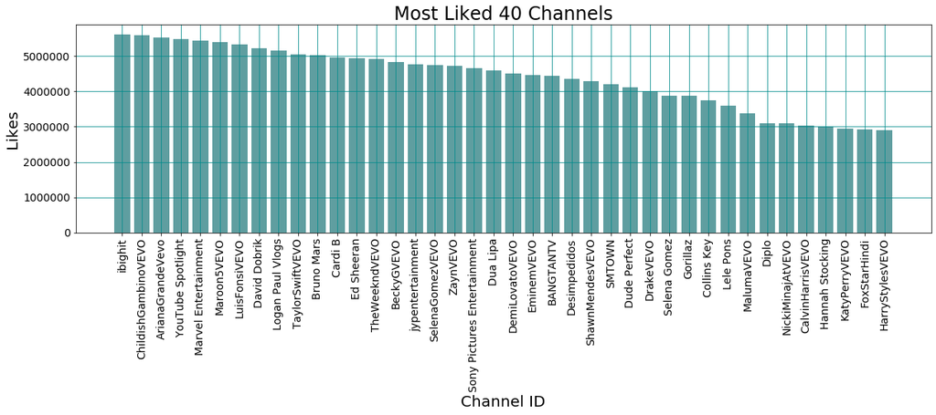

```python
US_df_likes_sorted=US_df.sort_values("likes",ascending= False)
plt.figure(figsize=(20,5))
#plt.plot(US_df_likes_sorted['channel_title'].unique()[0:99],US_df_likes_sorted['likes'][0:99],color="red",marker="X",markersize=15)
#plt.scatter( US_df_likes_sorted['likes'][0:99],US_df_likes_sorted['channel_title'].unique()[0:99],color="red",marker="X")
plt.bar(US_df_likes_sorted['channel_title'].unique()[0:40],US_df_likes_sorted['likes'][0:40],color="cadetblue")
plt.yticks(rotation=0,fontsize=14)
plt.xticks(rotation=90,fontsize=14)
plt.ticklabel_format(axis='y',style='sci',scilimits=(0,30))
plt.ylabel("Likes", size=20)
plt.xlabel("Channel ID", size=20)
plt.title("Most Liked 40 Channels",size=24)
plt.grid(color='darkcyan', linestyle='-', linewidth=0.8)

plt.show()
```

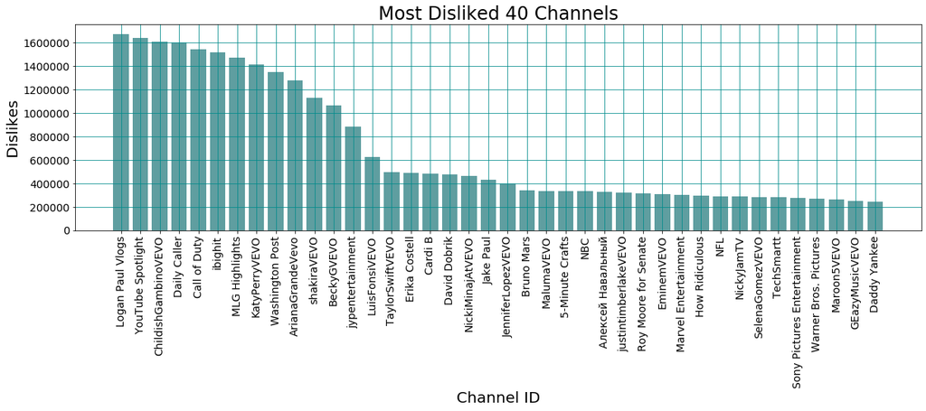

```python
US_df_dislikes_sorted=US_df.sort_values("dislikes",ascending= False)
plt.figure(figsize=(20,5))
#plt.plot(US_df_dislikes_sorted['channel_title'].unique()[0:99],US_df_dislikes_sorted['dislikes'][0:99],color="red",marker="X",markersize=15)
#plt.scatter( US_df_dislikes_sorted['dislikes'][0:99],US_df_dislikes_sorted['channel_title'].unique()[0:99],color="red",marker="X")
plt.bar(US_df_dislikes_sorted['channel_title'].unique()[0:40],US_df_dislikes_sorted['dislikes'][0:40],color="cadetblue")
plt.yticks(rotation=0,fontsize=14)
plt.xticks(rotation=90,fontsize=14)
plt.ticklabel_format(axis='y',style='sci',scilimits=(0,30))
plt.ylabel("Dislikes", size=20)
plt.xlabel("Channel ID", size=20)
plt.title("Most Disliked 40 Channels",size=24)
plt.grid(color='darkcyan', linestyle='-', linewidth=0.8)

plt.show()
```

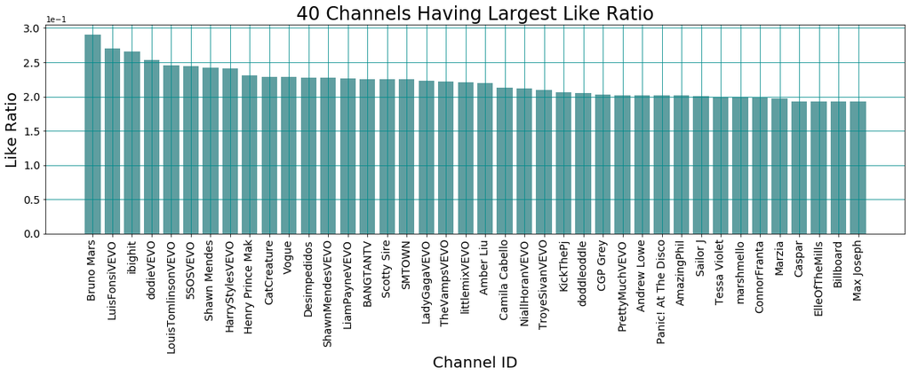

```python
US_df['like_ratio']=US_df['likes']/US_df['views'].round(5)
US_df_views_sorted=US_df.sort_values("like_ratio",ascending= False)
plt.figure(figsize=(20,5))
#plt.plot(US_df_views_sorted['channel_title'].unique()[0:99],US_df_views_sorted['views'][0:99],color="red",marker="X",markersize=15)
#plt.scatter( US_df_views_sorted['views'][0:99],US_df_views_sorted['channel_title'].unique()[0:99],color="red",marker="X")
plt.bar(US_df_views_sorted['channel_title'].unique()[0:40],US_df_views_sorted['like_ratio'][0:40],color="cadetblue")
plt.yticks(rotation=0,fontsize=14)
plt.xticks(rotation=90,fontsize=14)
plt.ticklabel_format(axis='y',style='sci',scilimits=(0,30))
plt.ylabel("Like Ratio", size=20)
plt.xlabel("Channel ID", size=20)
plt.title("40 Channels Having Largest Like Ratio",size=24)
plt.grid(color='darkcyan', linestyle='-', linewidth=0.8)

plt.show()
```

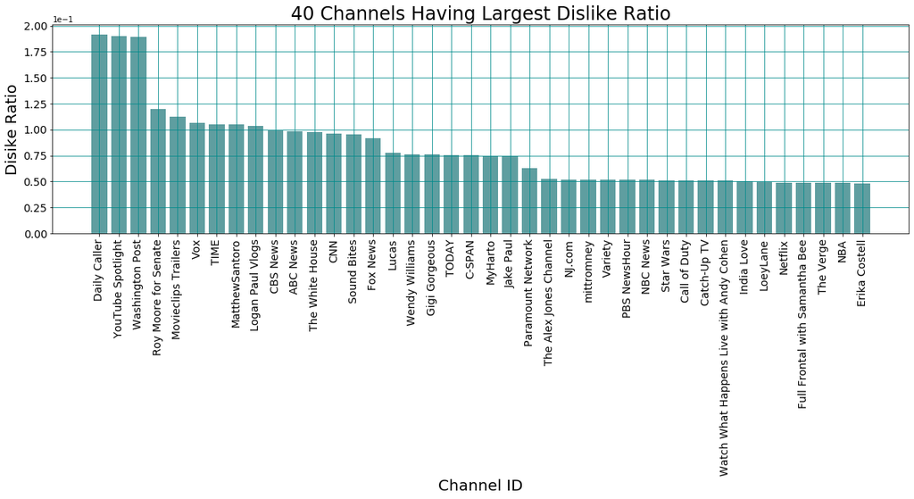

```python
US_df['dislike_ratio']=US_df['dislikes']/US_df['views'].round(5)
US_df_views_sorted=US_df.sort_values("dislike_ratio",ascending= False)
plt.figure(figsize=(20,5))
#plt.plot(US_df_views_sorted['channel_title'].unique()[0:99],US_df_views_sorted['views'][0:99],color="red",marker="X",markersize=15)
#plt.scatter( US_df_views_sorted['views'][0:99],US_df_views_sorted['channel_title'].unique()[0:99],color="red",marker="X")
plt.bar(US_df_views_sorted['channel_title'].unique()[0:40],US_df_views_sorted['dislike_ratio'][0:40],color="cadetblue")
plt.yticks(rotation=0,fontsize=14)
plt.xticks(rotation=90,fontsize=14)
plt.ticklabel_format(axis='y',style='sci',scilimits=(0,30))
plt.ylabel("Disike Ratio", size=20)
plt.xlabel("Channel ID", size=20)
plt.title("40 Channels Having Largest Dislike Ratio",size=24)
plt.grid(color='darkcyan', linestyle='-', linewidth=0.8)

plt.show()
```

##### 3.2. Category ID vs Views, Likes and Dislikes

```python
US_df_category_id = US_df.groupby('category_id').agg({'views': ['count','sum', np.mean],'likes': ['sum', np.mean],'dislikes': ['sum', np.mean], 'like_ratio': np.mean, 'dislike_ratio': np.mean}).round(5)
US_df_category_id.columns = ['count','view_sum','view_avg','like_sum','like_avg','dislike_sum','dislike_avg','like_ratio_avg','dislike_ratio_avg']
```

```python
US_df_category_id
```

| category_id | count | view_sum | view_avg | like_sum | like_avg | dislike_sum | dislike_avg | like_ratio_avg | dislike_ratio_avg |
| --- | --- | --- | --- | --- | --- | --- | --- | --- | --- |
| 1 | 2343 | 7267792432 | 3.101917e+06 | 165604731 | 70680.63636 | 6071246 | 2591.22749 | 0.02741 | 0.00142 |
| 2 | 384 | 520690717 | 1.355965e+06 | 4245656 | 11056.39583 | 243010 | 632.83854 | 0.01690 | 0.00095 |
| 10 | 6467 | 40126286541 | 6.204776e+06 | 1416572741 | 219046.34931 | 51173364 | 7912.99892 | 0.04757 | 0.00126 |
| 15 | 920 | 764651989 | 8.311435e+05 | 19370702 | 21055.11087 | 527379 | 573.23804 | 0.03347 | 0.00075 |
| 17 | 2172 | 4403213872 | 2.027262e+06 | 98614929 | 45402.82182 | 5132721 | 2363.13122 | 0.01528 | 0.00100 |
| 19 | 401 | 343100609 | 8.556125e+05 | 4825685 | 12034.12718 | 340090 | 848.10474 | 0.02080 | 0.00131 |
| 20 | 816 | 2127799781 | 2.607598e+06 | 68779564 | 84288.68137 | 9161661 | 11227.52574 | 0.03732 | 0.00254 |
| 22 | 3208 | 4910004664 | 1.530550e+06 | 186350335 | 58089.25655 | 10178864 | 3172.96259 | 0.04181 | 0.00205 |
| 23 | 3453 | 5111266590 | 1.480239e+06 | 216136310 | 62593.77643 | 7219986 | 2090.93136 | 0.04387 | 0.00153 |
| 24 | 9942 | 20556160491 | 2.067608e+06 | 529223051 | 53231.04516 | 42901165 | 4315.14434 | 0.02853 | 0.00159 |
| 25 | 2485 | 1473090484 | 5.927930e+05 | 18137189 | 7298.66761 | 4179491 | 1681.88773 | 0.01269 | 0.00395 |
| 26 | 4142 | 4071011870 | 9.828614e+05 | 162515891 | 39236.09150 | 5462302 | 1318.75954 | 0.04499 | 0.00134 |
| 27 | 1653 | 1173284058 | 7.097907e+05 | 48852267 | 29553.70054 | 1348334 | 815.68905 | 0.03775 | 0.00128 |
| 28 | 2397 | 3473462753 | 1.449088e+06 | 82255009 | 34315.81519 | 4531899 | 1890.65457 | 0.03062 | 0.00139 |
| 29 | 57 | 168941392 | 2.963884e+06 | 14815646 | 259923.61404 | 3310381 | 58076.85965 | 0.03790 | 0.00397 |
| 43 | 57 | 51501058 | 9.035273e+05 | 1082639 | 18993.66667 | 24508 | 429.96491 | 0.02214 | 0.00074 |

```python
US_df_category_id["category_id"]=US_df_category_id.index
```

```python
US_df_category_id["category_id"]=US_df_category_id["category_id"].astype(str)
```

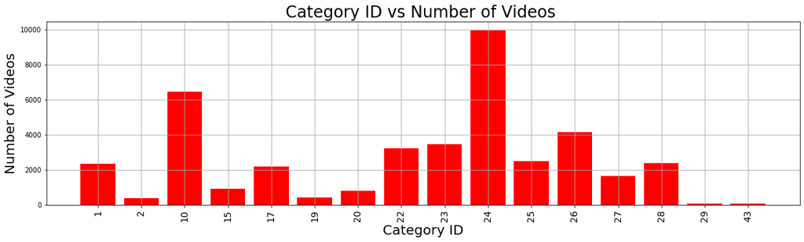

```python
plt.figure(figsize=(20,5))
plt.grid(color='darkgrey', linestyle='-', linewidth=0.8)
plt.bar(US_df_category_id['category_id'],US_df_category_id['count'],color="red")
plt.ticklabel_format(axis='y',style='sci',scilimits=(0,30))
plt.xticks(rotation=90,fontsize=14)
plt.ylabel("Number of Videos", size=20)
plt.xlabel("Category ID", size=20)
plt.title("Category ID vs Number of Videos ",size=24)
plt.show()
```

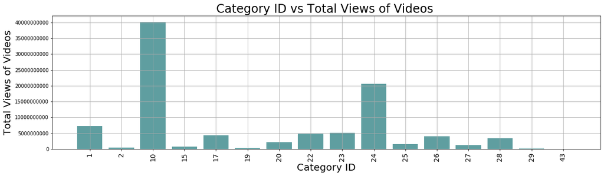

```python
plt.figure(figsize=(20,5))
plt.grid(color='darkgrey', linestyle='-', linewidth=0.8)
plt.bar(US_df_category_id['category_id'],US_df_category_id['view_sum'],color="cadetblue")
plt.ticklabel_format(axis='y',style='sci',scilimits=(0,30))
plt.xticks(rotation=90,fontsize=14)
plt.ylabel("Total Views of Videos", size=20)
plt.xlabel("Category ID", size=20)
plt.title("Category ID vs Total Views of Videos ",size=24)
plt.show()
```

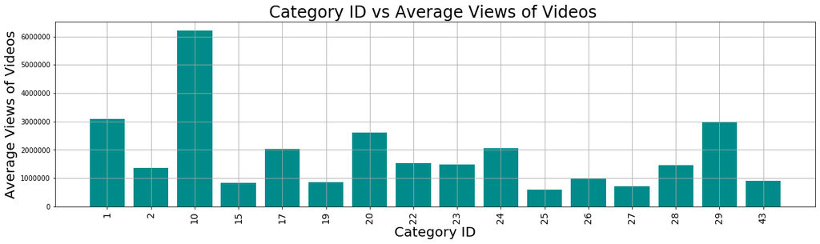

```python
plt.figure(figsize=(20,5))
plt.grid(color='darkgrey', linestyle='-', linewidth=0.8)
plt.bar(US_df_category_id['category_id'],US_df_category_id['view_avg'],color="darkcyan")
plt.ticklabel_format(axis='y',style='sci',scilimits=(0,30))
plt.xticks(rotation=90,fontsize=14)
plt.ylabel("Average Views of Videos", size=20)
plt.xlabel("Category ID", size=20)
plt.title("Category ID vs Average Views of Videos ",size=24)
plt.show()
```

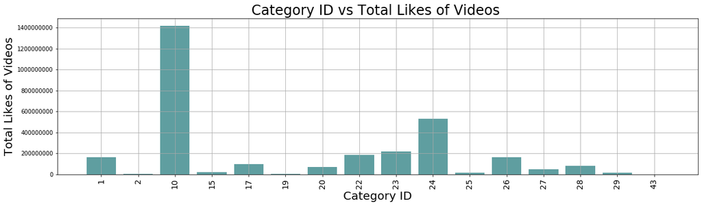

```python
plt.figure(figsize=(20,5))
plt.grid(color='darkgrey', linestyle='-', linewidth=0.8)
plt.bar(US_df_category_id['category_id'],US_df_category_id['like_sum'],color="cadetblue")
plt.ticklabel_format(axis='y',style='sci',scilimits=(0,30))
plt.xticks(rotation=90,fontsize=14)
plt.ylabel("Total Likes of Videos", size=20)
plt.xlabel("Category ID", size=20)
plt.title("Category ID vs Total Likes of Videos ",size=24)
plt.show()
```

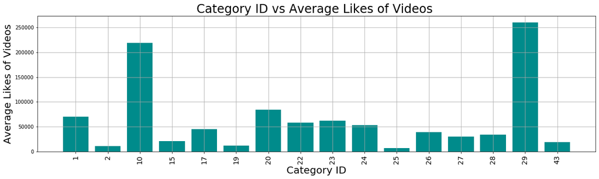

```python
plt.figure(figsize=(20,5))
plt.grid(color='darkgrey', linestyle='-', linewidth=0.8)
plt.bar(US_df_category_id['category_id'],US_df_category_id['like_avg'],color="darkcyan")
plt.ticklabel_format(axis='y',style='sci',scilimits=(0,30))
plt.xticks(rotation=90,fontsize=14)
plt.ylabel("Average Likes of Videos", size=20)
plt.xlabel("Category ID", size=20)
plt.title("Category ID vs Average Likes of Videos ",size=24)
plt.show()
```

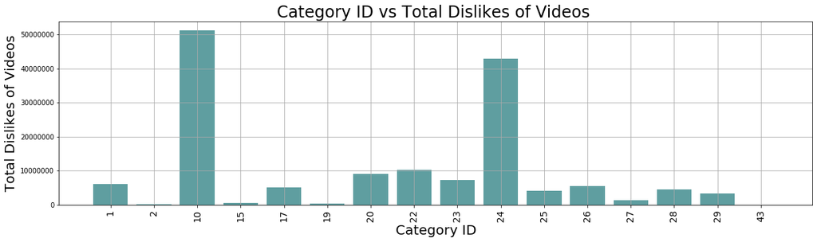

```python
plt.figure(figsize=(20,5))
plt.grid(color='darkgrey', linestyle='-', linewidth=0.8)
plt.bar(US_df_category_id['category_id'],US_df_category_id['dislike_sum'],color="cadetblue")
plt.ticklabel_format(axis='y',style='sci',scilimits=(0,30))
plt.xticks(rotation=90,fontsize=14)
plt.ylabel("Total Dislikes of Videos", size=20)
plt.xlabel("Category ID", size=20)
plt.title("Category ID vs Total Dislikes of Videos ",size=24)
plt.show()
```

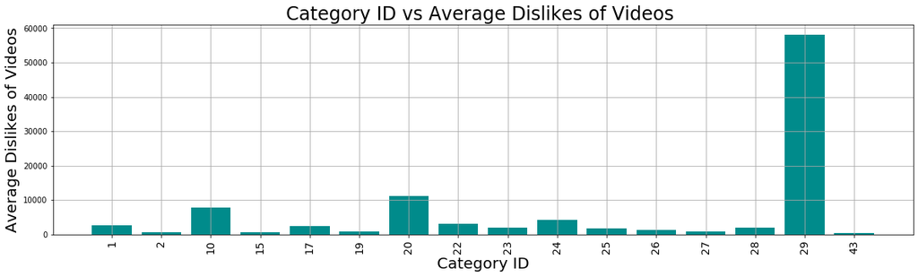

```python
plt.figure(figsize=(20,5))
plt.grid(color='darkgrey', linestyle='-', linewidth=0.8)
plt.bar(US_df_category_id['category_id'],US_df_category_id['dislike_avg'],color="darkcyan")
plt.ticklabel_format(axis='y',style='sci',scilimits=(0,30))
plt.xticks(rotation=90,fontsize=14)
plt.ylabel("Average Dislikes of Videos", size=20)
plt.xlabel("Category ID", size=20)
plt.title("Category ID vs Average Dislikes of Videos ",size=24)
plt.show()
```

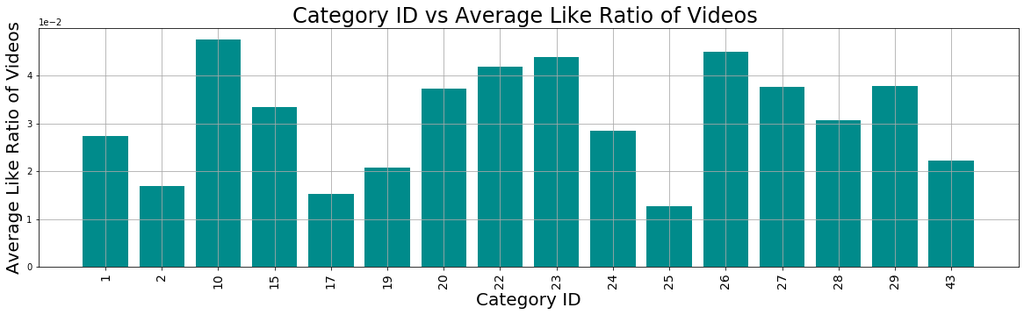

```python
plt.figure(figsize=(20,5))
plt.grid(color='darkgrey', linestyle='-', linewidth=0.8)
plt.bar(US_df_category_id['category_id'],US_df_category_id['like_ratio_avg'],color="darkcyan")
plt.ticklabel_format(axis='y',style='sci',scilimits=(0,30))
plt.xticks(rotation=90,fontsize=14)
plt.ylabel("Average Like Ratio of Videos", size=20)
plt.xlabel("Category ID", size=20)
plt.title("Category ID vs Average Like Ratio of Videos ",size=24)
plt.show()
```

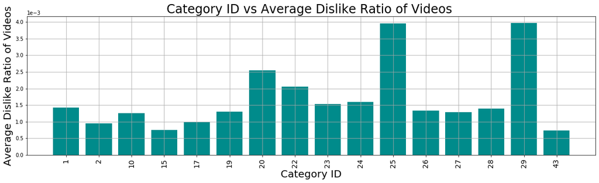

```python
plt.figure(figsize=(20,5))
plt.grid(color='darkgrey', linestyle='-', linewidth=0.8)
plt.bar(US_df_category_id['category_id'],US_df_category_id['dislike_ratio_avg'],color="darkcyan")
plt.ticklabel_format(axis='y',style='sci',scilimits=(0,30))
plt.xticks(rotation=90,fontsize=14)
plt.ylabel("Average Dislike Ratio of Videos", size=20)
plt.xlabel("Category ID", size=20)
plt.title("Category ID vs Average Dislike Ratio of Videos ",size=24)
plt.show()
```

##### 3.3. Comments_disabled vs Views, Likes and Dislikes

```python
US_df.groupby('comments_disabled').agg({'views': ['count','sum', np.mean],'likes': ['sum', np.mean],'dislikes': ['sum', np.mean], 'like_ratio': np.mean, 'dislike_ratio': np.mean}).round(5)
```

| comments_disabled | views count | views sum | views mean | likes sum | likes mean | dislikes sum | dislikes mean | like_ratio mean | dislike_ratio mean |
| --- | --- | --- | --- | --- | --- | --- | --- | --- | --- |
| False | 40265 | 94949564807 | 2.358117e+06 | 3023833030 | 75098.29952 | 150107651 | 3727.99332 | 0.03476 | 0.00160 |
| True | 632 | 1592694494 | 2.520086e+06 | 13549315 | 21438.78956 | 1698750 | 2687.89557 | 0.01271 | 0.00281 |

##### 3.4. Ratings_disabled vs Views, Likes and Dislikes

```python
US_df.groupby('ratings_disabled').agg({'views': ['count','sum', np.mean],'likes': ['sum', np.mean],'dislikes': ['sum', np.mean], 'like_ratio': np.mean, 'dislike_ratio': np.mean}).round(5)
```

| ratings_disabled | views count | views sum | views mean | likes sum | likes mean | dislikes sum | dislikes mean | like_ratio mean | dislike_ratio mean |
| --- | --- | --- | --- | --- | --- | --- | --- | --- | --- |
| False | 40728 | 95845233135 | 2.353301e+06 | 3037382345 | 74577.25263 | 151806401 | 3727.32275 | 0.03456 | 0.00162 |
| True | 169 | 697026166 | 4.124415e+06 | 0 | 0.00000 | 0 | 0.00000 | 0.00000 | 0.00000 |

##### 3.5. Video_error_or_removed vs Views, Likes and Dislikes

```python
US_df.groupby('video_error_or_removed').agg({'views': ['count','sum', np.mean],'likes': ['sum', np.mean],'dislikes': ['sum', np.mean], 'like_ratio': np.mean, 'dislike_ratio': np.mean}).round(5)
```

| video_error_or_removed | views count | views sum | views mean | likes sum | likes mean | dislikes sum | dislikes mean | like_ratio mean | dislike_ratio mean |
| --- | --- | --- | --- | --- | --- | --- | --- | --- | --- |
| False | 40874 | 96504146229 | 2.361015e+06 | 3036260625 | 74283.42284 | 151773221 | 3713.19717 | 0.03442 | 0.00161 |
| True | 23 | 38113072 | 1.657090e+06 | 1121720 | 48770.43478 | 33180 | 1442.60870 | 0.03087 | 0.00156 |

#### 3.6 Correlations between numeric variables

```python
#Calculate time since publishment
US_df['days_difference'] = (US_df['trending_date'].dt.date-US_df['publish_time'].dt.date).dt.days
```

```python
numeric_var_list = ['views','likes','dislikes','comment_count','like_ratio','dislike_ratio','days_difference']
```

```python
corr = US_df[numeric_var_list].corr()
```

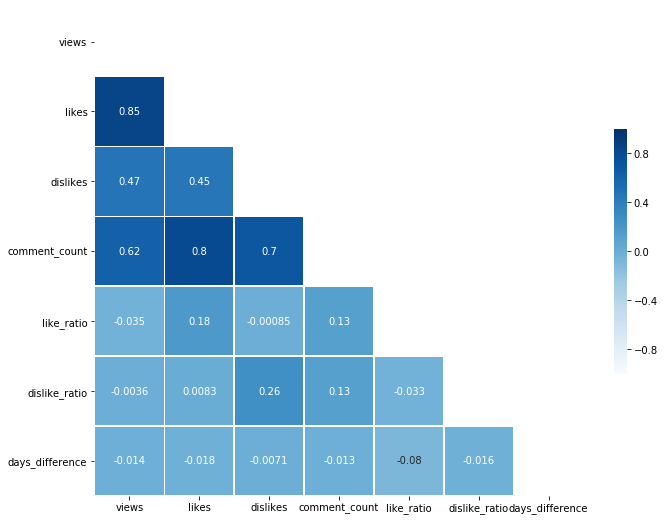

```python
mask = np.zeros_like(corr, dtype=np.bool)
mask[np.triu_indices_from(mask)] = True

f, ax = plt.subplots(figsize=(11, 9))

sns.heatmap(corr, mask=mask, cmap='Blues', vmax=1,vmin=-1,
            center=0,
            square=True, linewidths=.5, cbar_kws={"shrink": .5}, annot=True)
```

As expected correlation between

- views and likes
- comment_counts and likes/dislikes

are high

#### 3.7 Outliers in continuous numeric variables

- Outliers in continuous variables may affect analyses. I will remove the outliers in following columns: 'views','likes','dislikes','comment_count','days_difference'

```python
z = pd.DataFrame(np.abs(stats.zscore(US_df[['days_difference','likes','dislikes','comment_count','views']])),columns=['days_difference','likes','dislikes','comment_count','views'])
```

```python
z.count()
```

```
days_difference    40897
likes              40897
dislikes           40897
comment_count      40897
views              40897
dtype: int64
```

```python
z[(z['days_difference']<=3)&(z['likes']<=3)&(z['dislikes']<=3)&(z['comment_count']<=3)&(z['views']<=3)].count()
```

```
days_difference    39811
likes              39811
dislikes           39811
comment_count      39811
views              39811
dtype: int64
```

```python
print('Count of observations will be removed as outliers: ', str(40897-39811))
```

```
Count of observations will be removed as outliers:  1086
```

```python
US_df_continuous = US_df[['days_difference','likes','dislikes','comment_count','views']]
US_df_continuous = US_df_continuous[(np.abs(stats.zscore(US_df_continuous)) <=3).all(axis=1)]
```

- Join binary&categorical variables to be used in model to outlier-eliminated data

```python
US_df_continuous = pd.merge(US_df_continuous,US_df[['category_id','video_error_or_removed','comments_disabled','ratings_disabled','like_ratio','dislike_ratio']],how='left',right_index=True, left_index=True)
```

```python
#replace the data and delete the other
US_df = US_df_continuous.copy()
del US_df_continuous
```

```python
corr2 = US_df[numeric_var_list].corr()
```

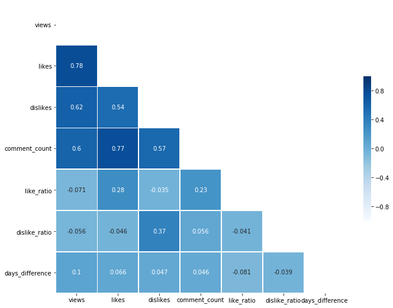

```python
mask = np.zeros_like(corr2, dtype=np.bool)
mask[np.triu_indices_from(mask)] = True

f, ax = plt.subplots(figsize=(11, 9))

sns.heatmap(corr2, mask=mask, cmap='Blues', vmax=1,vmin=-1,
            center=0,
            square=True, linewidths=.5, cbar_kws={"shrink": .5}, annot=True)
```

##### 3.8. Aggregated TimeSincePublihment vs Views, Likes and Dislikes

```python
US_df['days_difference'].describe(percentiles=[0.01,0.99]).to_frame()
```

|  | days_difference |
| --- | --- |
| count | 39811.000000 |
| mean | 6.953556 |
| std | 11.973045 |
| min | 0.000000 |
| 1% | 1.000000 |
| 50% | 5.000000 |
| 99% | 25.000000 |
| max | 409.000000 |

```python
US_df['days_difference_band'] = pd.qcut(US_df['days_difference'],
                            q=[x for x in np.arange(0, 1.01,0.01)],
                            duplicates = 'drop')
```

```python
US_df['days_difference_band'].value_counts()
```

```
(3.0, 4.0]       4620
(2.0, 3.0]       4582
(4.0, 5.0]       4515
(1.0, 2.0]       4235
(5.0, 6.0]       3970
(6.0, 7.0]       3062
(-0.001, 1.0]    2934
(7.0, 8.0]       2124
(8.0, 9.0]       1611
(9.0, 10.0]      1331
(10.0, 11.0]     1164
(11.0, 12.0]     1048
(12.0, 13.0]      904
(13.0, 14.0]      762
(14.0, 15.0]      575
(17.0, 19.0]      496
(15.0, 16.0]      440
(21.0, 25.0]      411
(16.0, 17.0]      372
(25.0, 409.0]     350
(19.0, 21.0]      305
Name: days_difference_band, dtype: int64
```

```python
days_diffrence_band_df = US_df.groupby('days_difference_band').agg({'days_difference':np.mean,'views':np.mean, 'likes': np.mean, 'dislikes': np.mean, 'like_ratio': np.mean, 'dislike_ratio': np.mean})
days_diffrence_band_df.columns = ['days_difference_avg','views_avg','likes_avg','dislikes_avg','like_ratio_avg','dislike_ratio_avg']
days_diffrence_band_df.round(5)
```

| days_difference_band | days_difference_avg | views_avg | likes_avg | dislikes_avg | like_ratio_avg | dislike_ratio_avg |
| --- | --- | --- | --- | --- | --- | --- |
| (-0.001, 1.0] | 0.95876 | 6.760467e+05 | 30123.17519 | 1097.36605 | 0.04462 | 0.00208 |
| (1.0, 2.0] | 2.00000 | 9.546227e+05 | 36585.02621 | 1476.98158 | 0.03797 | 0.00178 |
| (2.0, 3.0] | 3.00000 | 1.080146e+06 | 38321.04168 | 1566.45242 | 0.03547 | 0.00168 |
| (3.0, 4.0] | 4.00000 | 1.187092e+06 | 40021.58095 | 1686.26320 | 0.03451 | 0.00160 |
| (4.0, 5.0] | 5.00000 | 1.266455e+06 | 41399.31096 | 1725.12558 | 0.03384 | 0.00154 |
| (5.0, 6.0] | 6.00000 | 1.439959e+06 | 45281.83778 | 1914.42695 | 0.03317 | 0.00154 |
| (6.0, 7.0] | 7.00000 | 1.756434e+06 | 53174.47518 | 2287.08850 | 0.03218 | 0.00151 |
| (7.0, 8.0] | 8.00000 | 1.937217e+06 | 57455.11158 | 2363.60687 | 0.03221 | 0.00141 |
| (8.0, 9.0] | 9.00000 | 2.103669e+06 | 62169.59094 | 2635.56052 | 0.03205 | 0.00141 |
| (9.0, 10.0] | 10.00000 | 2.267850e+06 | 66238.27198 | 2781.01277 | 0.03197 | 0.00139 |
| (10.0, 11.0] | 11.00000 | 2.282983e+06 | 67817.01460 | 2751.20619 | 0.03215 | 0.00137 |
| (11.0, 12.0] | 12.00000 | 2.446190e+06 | 72129.94370 | 2872.92653 | 0.03193 | 0.00131 |
| (12.0, 13.0] | 13.00000 | 2.755986e+06 | 78594.45022 | 3175.37389 | 0.03102 | 0.00123 |
| (13.0, 14.0] | 14.00000 | 2.938459e+06 | 80960.80184 | 3346.56430 | 0.03064 | 0.00124 |
| (14.0, 15.0] | 15.00000 | 3.252135e+06 | 87473.12696 | 3607.90609 | 0.03000 | 0.00121 |
| (15.0, 16.0] | 16.00000 | 3.381955e+06 | 90448.72955 | 3628.41364 | 0.03004 | 0.00118 |
| (16.0, 17.0] | 17.00000 | 3.803099e+06 | 99013.50538 | 4019.45968 | 0.02929 | 0.00118 |
| (17.0, 19.0] | 18.41532 | 4.301835e+06 | 110644.21371 | 4454.57258 | 0.02935 | 0.00118 |
| (19.0, 21.0] | 20.46557 | 4.613565e+06 | 121149.91148 | 4266.07213 | 0.02935 | 0.00101 |
| (21.0, 25.0] | 23.35766 | 5.016406e+06 | 123654.93674 | 4429.41606 | 0.02778 | 0.00099 |
| (25.0, 409.0] | 74.06857 | 3.690928e+06 | 84149.33143 | 3048.02857 | 0.01984 | 0.00104 |

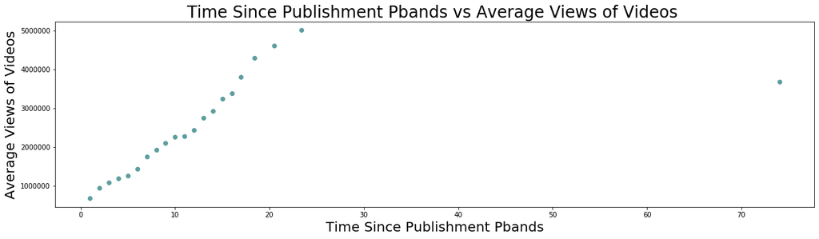

```python
plt.figure(figsize=(20,5))
plt.scatter(days_diffrence_band_df.reset_index()['days_difference_avg'],days_diffrence_band_df.reset_index()['views_avg'],color="cadetblue")
plt.ylabel("Average Views of Videos", size=20)
plt.xlabel("Time Since Publishment Pbands", size=20)
plt.title("Time Since Publishment Pbands vs Average Views of Videos ",size=24)
plt.show()
```

- Last band seems like outlier, remove it

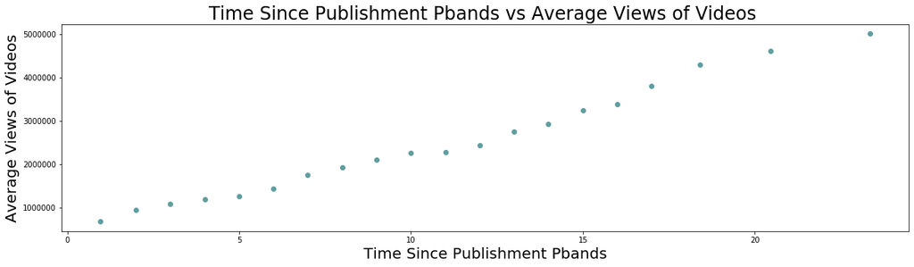

```python
days_diffrence_band_df = days_diffrence_band_df[days_diffrence_band_df['days_difference_avg']<74]
plt.figure(figsize=(20,5))
plt.scatter(days_diffrence_band_df.reset_index()['days_difference_avg'],days_diffrence_band_df.reset_index()['views_avg'],color="cadetblue")
plt.ylabel("Average Views of Videos", size=20)
plt.xlabel("Time Since Publishment Pbands", size=20)
plt.title("Time Since Publishment Pbands vs Average Views of Videos ",size=24)
plt.show()
```

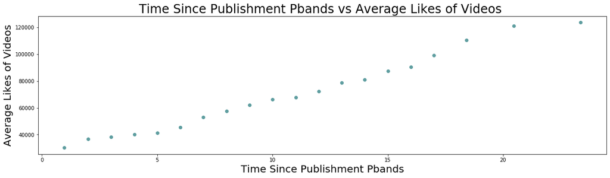

```python
plt.figure(figsize=(20,5))
plt.scatter(days_diffrence_band_df.reset_index()['days_difference_avg'],days_diffrence_band_df.reset_index()['likes_avg'],color="cadetblue")
plt.ylabel("Average Likes of Videos", size=20)
plt.xlabel("Time Since Publishment Pbands", size=20)
plt.title("Time Since Publishment Pbands vs Average Likes of Videos ",size=24)
plt.show()
```

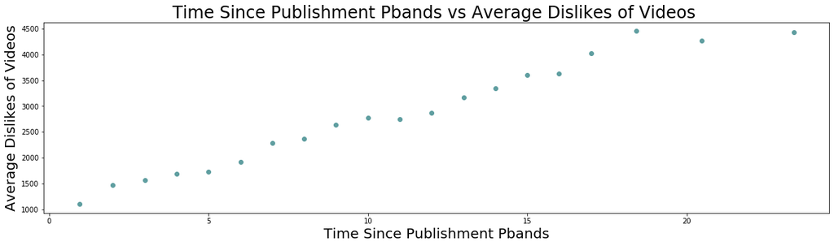

```python
plt.figure(figsize=(20,5))
plt.scatter(days_diffrence_band_df.reset_index()['days_difference_avg'],days_diffrence_band_df.reset_index()['dislikes_avg'],color="cadetblue")
plt.ylabel("Average Dislikes of Videos", size=20)
plt.xlabel("Time Since Publishment Pbands", size=20)
plt.title("Time Since Publishment Pbands vs Average Dislikes of Videos ",size=24)
plt.show()
```

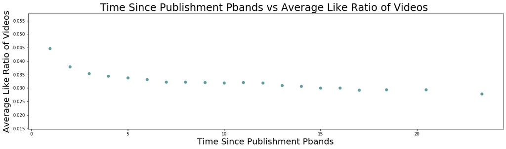

```python
plt.figure(figsize=(20,5))
plt.scatter(days_diffrence_band_df.reset_index()['days_difference_avg'],days_diffrence_band_df.reset_index()['like_ratio_avg'],color="cadetblue")
plt.ylabel("Average Like Ratio of Videos", size=20)
plt.xlabel("Time Since Publishment Pbands", size=20)
plt.title("Time Since Publishment Pbands vs Average Like Ratio of Videos ",size=24)
plt.show()
```

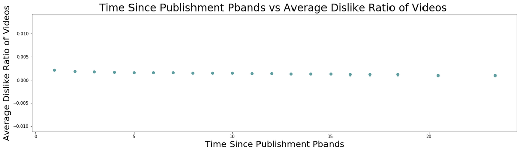

```python
plt.figure(figsize=(20,5))
plt.scatter(days_diffrence_band_df.reset_index()['days_difference_avg'],days_diffrence_band_df.reset_index()['dislike_ratio_avg'],color="cadetblue")
plt.ylabel("Average Dislike Ratio of Videos", size=20)
plt.xlabel("Time Since Publishment Pbands", size=20)
plt.title("Time Since Publishment Pbands vs Average Dislike Ratio of Videos ",size=24)
plt.show()
```

```python
days_diffrence_band_df.corr()
```

|  | days_difference_avg | views_avg | likes_avg | dislikes_avg | like_ratio_avg | dislike_ratio_avg |
| --- | --- | --- | --- | --- | --- | --- |
| days_difference_avg | 1.000000 | 0.992247 | 0.992400 | 0.987177 | -0.839536 | -0.943407 |
| views_avg | 0.992247 | 1.000000 | 0.998464 | 0.986364 | -0.809314 | -0.916636 |
| likes_avg | 0.992400 | 0.998464 | 1.000000 | 0.987768 | -0.804348 | -0.918523 |
| dislikes_avg | 0.987177 | 0.986364 | 0.987768 | 1.000000 | -0.847701 | -0.935295 |
| like_ratio_avg | -0.839536 | -0.809314 | -0.804348 | -0.847701 | 1.000000 | 0.958130 |
| dislike_ratio_avg | -0.943407 | -0.916636 | -0.918523 | -0.935295 | 0.958130 | 1.000000 |

- Relation btw time since published band averages and views averages

```python
X = days_diffrence_band_df[['days_difference_avg']]
y = days_diffrence_band_df[['views_avg']]

X2 = sm.add_constant(X)
est = sm.OLS(y, X2)
est2 = est.fit()
print(est2.summary())
```

```
                            OLS Regression Results
==============================================================================
Dep. Variable:              views_avg   R-squared:                       0.985
Model:                            OLS   Adj. R-squared:                  0.984
Method:                 Least Squares   F-statistic:                     1147.
Date:                Mon, 06 Jan 2020   Prob (F-statistic):           9.35e-18
Time:                        20:24:29   Log-Likelihood:                -267.22
No. Observations:                  20   AIC:                             538.4
Df Residuals:                      18   BIC:                             540.4
Df Model:                           1
Covariance Type:            nonrobust
=======================================================================================
                          coef    std err          t      P>|t|      [0.025      0.975]
---------------------------------------------------------------------------------------
const                3.502e+05   7.24e+04      4.838      0.000    1.98e+05    5.02e+05
days_difference_avg  1.973e+05   5824.729     33.873      0.000    1.85e+05     2.1e+05
==============================================================================
Omnibus:                        0.299   Durbin-Watson:                   0.530
Prob(Omnibus):                  0.861   Jarque-Bera (JB):                0.465
Skew:                           0.182   Prob(JB):                        0.793
Kurtosis:                       2.348   Cond. No.                         25.0
==============================================================================

Warnings:
[1] Standard Errors assume that the covariance matrix of the errors is correctly specified.
```

- Relation btw time since published band averages and like ratio averages

```python
X = days_diffrence_band_df[['days_difference_avg']]
y = days_diffrence_band_df[['like_ratio_avg']]

X2 = sm.add_constant(X)
est = sm.OLS(y, X2)
est2 = est.fit()
print(est2.summary())
```

```
                            OLS Regression Results
==============================================================================
Dep. Variable:         like_ratio_avg   R-squared:                       0.705
Model:                            OLS   Adj. R-squared:                  0.688
Method:                 Least Squares   F-statistic:                     42.98
Date:                Mon, 06 Jan 2020   Prob (F-statistic):           3.68e-06
Time:                        20:24:29   Log-Likelihood:                 96.194
No. Observations:                  20   AIC:                            -188.4
Df Residuals:                      18   BIC:                            -186.4
Df Model:                           1
Covariance Type:            nonrobust
=======================================================================================
                          coef    std err          t      P>|t|      [0.025      0.975]
---------------------------------------------------------------------------------------
const                   0.0378      0.001     40.630      0.000       0.036       0.040
days_difference_avg    -0.0005   7.48e-05     -6.556      0.000      -0.001      -0.000
==============================================================================
Omnibus:                       29.989   Durbin-Watson:                   0.585
Prob(Omnibus):                  0.000   Jarque-Bera (JB):               58.868
Skew:                           2.465   Prob(JB):                     1.65e-13
Kurtosis:                       9.807   Cond. No.                         25.0
==============================================================================

Warnings:
[1] Standard Errors assume that the covariance matrix of the errors is correctly specified.
```

##### 3.9. Aggregated Likes vs Views

```python
US_df['likes_band'] = pd.qcut(US_df['likes'],
                            q=[x for x in np.arange(0, 1.01,0.01)],
                            #labels=False,
                            duplicates = 'drop')
```

```python
US_df['likes_band'].value_counts()
```

```
(-0.001, 18.0]        411
(352.5, 469.0]        402
(965.0, 1170.0]       401
(13740.4, 14269.0]    400
(774.8, 965.0]        400
                     ...
(3484.0, 3790.0]      396
(144.0, 229.0]        395
(1170.0, 1371.2]      394
(469.0, 612.7]        394
(18.0, 70.0]          389
Name: likes_band, Length: 100, dtype: int64
```

```python
likes_band_df = US_df.groupby('likes_band').agg({'likes':np.mean,'views':np.mean})
likes_band_df.columns = ['likes_avg','views_avg']
likes_band_df.round(0)
```

| likes_band | likes_avg | views_avg |
| --- | --- | --- |
| (-0.001, 18.0] | 5.0 | 627366.0 |
| (18.0, 70.0] | 42.0 | 14660.0 |
| (70.0, 144.0] | 109.0 | 30698.0 |
| (144.0, 229.0] | 183.0 | 78467.0 |
| (229.0, 352.5] | 287.0 | 87035.0 |
| ... | ... | ... |
| (224800.0, 265593.2] | 242893.0 | 6479477.0 |
| (265593.2, 317069.1] | 288912.0 | 7925630.0 |
| (317069.1, 373546.0] | 344742.0 | 9654751.0 |
| (373546.0, 464311.5] | 413181.0 | 11907448.0 |
| (464311.5, 759589.0] | 566547.0 | 12621584.0 |

100 rows × 2 columns

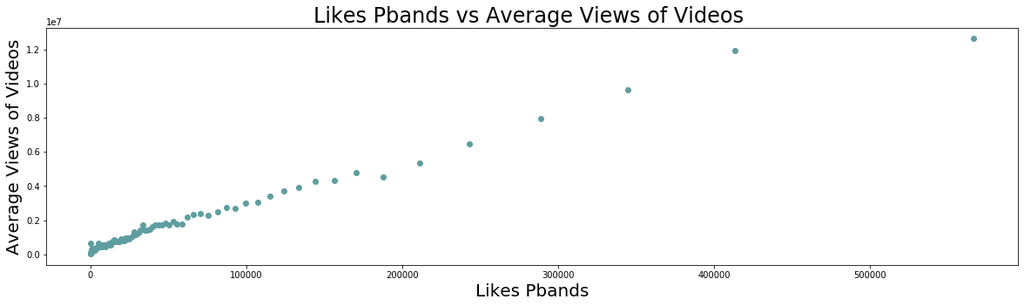

```python
plt.figure(figsize=(20,5))
plt.scatter(likes_band_df.reset_index()['likes_avg'],likes_band_df.reset_index()['views_avg'],color="cadetblue")
plt.ylabel("Average Views of Videos", size=20)
plt.xlabel("Likes Pbands", size=20)
plt.title("Likes Pbands vs Average Views of Videos ",size=24)
plt.show()
```

```python
#Correlation
likes_band_df.corr()
```

|  | likes_avg | views_avg |
| --- | --- | --- |
| likes_avg | 1.000000 | 0.991456 |
| views_avg | 0.991456 | 1.000000 |

```python
X = likes_band_df[['likes_avg']]
y = likes_band_df[['views_avg']]

X2 = sm.add_constant(X)
est = sm.OLS(y, X2)
est2 = est.fit()
print(est2.summary())
```

```
                            OLS Regression Results
==============================================================================
Dep. Variable:              views_avg   R-squared:                       0.983
Model:                            OLS   Adj. R-squared:                  0.983
Method:                 Least Squares   F-statistic:                     5662.
Date:                Mon, 06 Jan 2020   Prob (F-statistic):           1.66e-88
Time:                        20:24:30   Log-Likelihood:                -1400.5
No. Observations:                 100   AIC:                             2805.
Df Residuals:                      98   BIC:                             2810.
Df Model:                           1
Covariance Type:            nonrobust
==============================================================================
                 coef    std err          t      P>|t|      [0.025      0.975]
------------------------------------------------------------------------------
const       3.724e+05    3.4e+04     10.947      0.000    3.05e+05     4.4e+05
likes_avg     24.9175      0.331     75.243      0.000      24.260      25.575
==============================================================================
Omnibus:                       69.623   Durbin-Watson:                   1.417
Prob(Omnibus):                  0.000   Jarque-Bera (JB):             1338.517
Skew:                          -1.685   Prob(JB):                    2.21e-291
Kurtosis:                      20.604   Cond. No.                     1.18e+05
==============================================================================

Warnings:
[1] Standard Errors assume that the covariance matrix of the errors is correctly specified.
[2] The condition number is large, 1.18e+05. This might indicate that there are
strong multicollinearity or other numerical problems.
```

##### 3.10. Aggregated Dislikes vs Views

```python
US_df['dislikes_band'] = pd.qcut(US_df['dislikes'],
                            q=[x for x in np.arange(0, 1.01,0.01)],
                            #labels=False,
                            duplicates = 'drop')
dislikes_band_df = US_df.groupby('dislikes_band').agg({'likes':np.mean,'views':np.mean})
dislikes_band_df.columns = ['dislikes_avg','views_avg']
```

```python
dislikes_band_df.round(0)
```

| dislikes_band | dislikes_avg | views_avg |
| --- | --- | --- |
| (-0.001, 1.0] | 33.0 | 552590.0 |
| (1.0, 5.0] | 281.0 | 15827.0 |
| (5.0, 11.0] | 508.0 | 32678.0 |
| (11.0, 17.0] | 821.0 | 113388.0 |
| (17.0, 24.0] | 1207.0 | 72753.0 |
| ... | ... | ... |
| (9166.5, 10695.0] | 209597.0 | 7715666.0 |
| (10695.0, 12918.6] | 209962.0 | 8456711.0 |
| (12918.6, 16193.0] | 253995.0 | 9124042.0 |
| (16193.0, 23644.0] | 262078.0 | 8941194.0 |
| (23644.0, 87267.0] | 227867.0 | 9563190.0 |

100 rows × 2 columns

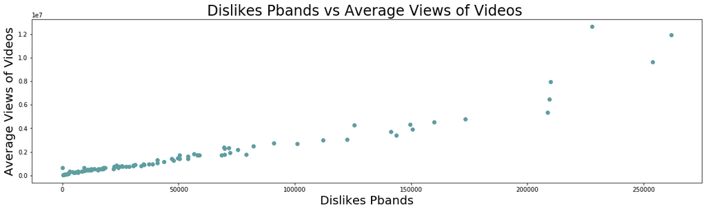

```python
plt.figure(figsize=(20,5))
plt.scatter(dislikes_band_df.reset_index()['dislikes_avg'],likes_band_df.reset_index()['views_avg'],color="cadetblue")
plt.ylabel("Average Views of Videos", size=20)
plt.xlabel("Dislikes Pbands", size=20)
plt.title("Dislikes Pbands vs Average Views of Videos ",size=24)
plt.show()
```

```python
#Correlation
dislikes_band_df.corr()
```

|  | dislikes_avg | views_avg |
| --- | --- | --- |
| dislikes_avg | 1.000000 | 0.984501 |
| views_avg | 0.984501 | 1.000000 |

```python
X = dislikes_band_df[['dislikes_avg']]
y = dislikes_band_df[['views_avg']]

X2 = sm.add_constant(X)
est = sm.OLS(y, X2)
est2 = est.fit()
print(est2.summary())
```

```
                            OLS Regression Results
==============================================================================
Dep. Variable:              views_avg   R-squared:                       0.969
Model:                            OLS   Adj. R-squared:                  0.969
Method:                 Least Squares   F-statistic:                     3088.
Date:                Mon, 06 Jan 2020   Prob (F-statistic):           6.64e-76
Time:                        20:24:30   Log-Likelihood:                -1422.8
No. Observations:                 100   AIC:                             2850.
Df Residuals:                      98   BIC:                             2855.
Df Model:                           1
Covariance Type:            nonrobust
================================================================================
                   coef    std err          t      P>|t|      [0.025      0.975]
--------------------------------------------------------------------------------
const        -9.123e+04   4.83e+04     -1.887      0.062   -1.87e+05    4719.382
dislikes_avg    33.9907      0.612     55.571      0.000      32.777      35.205
==============================================================================
Omnibus:                       48.684   Durbin-Watson:                   0.780
Prob(Omnibus):                  0.000   Jarque-Bera (JB):              408.584
Skew:                           1.239   Prob(JB):                     1.89e-89
Kurtosis:                      12.588   Cond. No.                     1.03e+05
==============================================================================

Warnings:
[1] Standard Errors assume that the covariance matrix of the errors is correctly specified.
[2] The condition number is large, 1.03e+05. This might indicate that there are
strong multicollinearity or other numerical problems.
```

remove constant

```python
est = sm.OLS(y, X)
est2 = est.fit()
print(est2.summary())
```

```
                                 OLS Regression Results
=======================================================================================
Dep. Variable:              views_avg   R-squared (uncentered):                   0.980
Model:                            OLS   Adj. R-squared (uncentered):              0.980
Method:                 Least Squares   F-statistic:                              4935.
Date:                Mon, 06 Jan 2020   Prob (F-statistic):                    2.80e-86
Time:                        20:24:30   Log-Likelihood:                         -1424.6
No. Observations:                 100   AIC:                                      2851.
Df Residuals:                      99   BIC:                                      2854.
Df Model:                           1
Covariance Type:            nonrobust
================================================================================
                   coef    std err          t      P>|t|      [0.025      0.975]
--------------------------------------------------------------------------------
dislikes_avg    33.2459      0.473     70.248      0.000      32.307      34.185
==============================================================================
Omnibus:                       67.657   Durbin-Watson:                   0.730
Prob(Omnibus):                  0.000   Jarque-Bera (JB):              644.443
Skew:                           1.920   Prob(JB):                    1.15e-140
Kurtosis:                      14.829   Cond. No.                         1.00
==============================================================================

Warnings:
[1] Standard Errors assume that the covariance matrix of the errors is correctly specified.
```

##### 3.11. Aggregated Comment Counts vs Views

```python
US_df['comment_count_band'] = pd.qcut(US_df['comment_count'],
                            q=[x for x in np.arange(0, 1.01,0.01)],
                            #labels=False,
                            duplicates = 'drop')
comment_count_band_df = US_df.groupby('comment_count_band').agg({'likes':np.mean,'views':np.mean})
comment_count_band_df.columns = ['comment_count_avg','views_avg']
```

```python
comment_count_band_df.round(0)
```

| comment_count_band | comment_count_avg | views_avg |
| --- | --- | --- |
| (-0.001, 2.0] | 16830.0 | 1423811.0 |
| (2.0, 15.0] | 3489.0 | 139856.0 |
| (15.0, 31.0] | 258.0 | 73282.0 |
| (31.0, 54.0] | 427.0 | 143545.0 |
| (54.0, 75.0] | 1079.0 | 89168.0 |
| ... | ... | ... |
| (23908.0, 27291.4] | 250534.0 | 6909644.0 |
| (27291.4, 31414.7] | 263103.0 | 8092585.0 |
| (31414.7, 37606.4] | 317708.0 | 8574548.0 |
| (37606.4, 49337.0] | 309059.0 | 7507683.0 |
| (49337.0, 120535.0] | 358731.0 | 8100667.0 |

99 rows × 2 columns

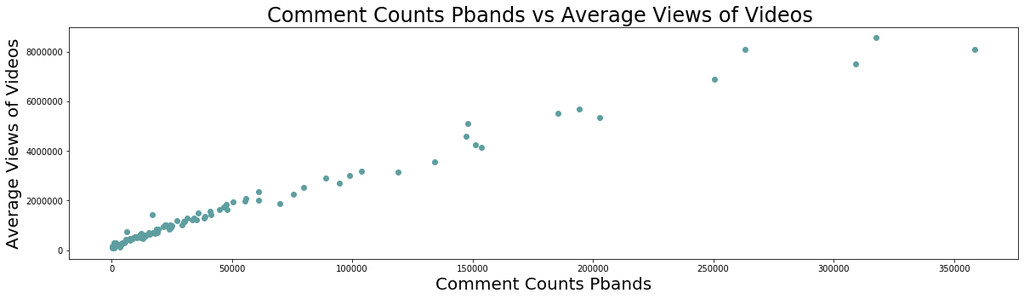

```python
plt.figure(figsize=(20,5))
plt.scatter(comment_count_band_df.reset_index()['comment_count_avg'],comment_count_band_df.reset_index()['views_avg'],color="cadetblue")
plt.ylabel("Average Views of Videos", size=20)
plt.xlabel("Comment Counts Pbands", size=20)
plt.title("Comment Counts Pbands vs Average Views of Videos ",size=24)
plt.show()
```

```python
comment_count_band_df.corr()
```

|  | comment_count_avg | views_avg |
| --- | --- | --- |
| comment_count_avg | 1.00000 | 0.98919 |
| views_avg | 0.98919 | 1.00000 |

```python
X = comment_count_band_df[['comment_count_avg']]
y = comment_count_band_df[['views_avg']]

X2 = sm.add_constant(X)
est = sm.OLS(y, X2)
est2 = est.fit()
print(est2.summary())
```

```
                            OLS Regression Results
==============================================================================
Dep. Variable:              views_avg   R-squared:                       0.978
Model:                            OLS   Adj. R-squared:                  0.978
Method:                 Least Squares   F-statistic:                     4414.
Date:                Mon, 06 Jan 2020   Prob (F-statistic):           1.09e-82
Time:                        20:24:31   Log-Likelihood:                -1382.5
No. Observations:                  99   AIC:                             2769.
Df Residuals:                      97   BIC:                             2774.
Df Model:                           1
Covariance Type:            nonrobust
=====================================================================================
                        coef    std err          t      P>|t|      [0.025      0.975]
-------------------------------------------------------------------------------------
const              3.238e+05   3.48e+04      9.314      0.000    2.55e+05    3.93e+05
comment_count_avg    25.7305      0.387     66.437      0.000      24.962      26.499
==============================================================================
Omnibus:                       30.757   Durbin-Watson:                   1.084
Prob(Omnibus):                  0.000   Jarque-Bera (JB):              307.729
Skew:                          -0.451   Prob(JB):                     1.50e-67
Kurtosis:                      11.590   Cond. No.                     1.09e+05
==============================================================================

Warnings:
[1] Standard Errors assume that the covariance matrix of the errors is correctly specified.
[2] The condition number is large, 1.09e+05. This might indicate that there are
strong multicollinearity or other numerical problems.
```

### 4. Linear Regression Model

#### Now, I will check whether there is a relationship between like ratio and some known variables: time since publishment, category id, rating_disabled, comments_disabled

- category_id cannot be used in model as is, it should be transformed to dummy variables

```python
category_df = pd.DataFrame(pd.get_dummies(US_df['category_id']))
category_df.columns = ['c_1','c_2','c_10','c_15','c_17','c_19','c_20','c_22','c_23','c_24','c_25','c_26','c_27','c_28','c_29','c_43']
```

- input & target dataframe preparation

variables like views, likes, dislikes cannot be used for prediction because their values are unknown till the time comes

```python
US_df_inputs = US_df[['comment_count','days_difference','comments_disabled','ratings_disabled']]
US_df_inputs = pd.merge(US_df_inputs,category_df,how='left',left_index=True,right_index=True)
US_df_target = US_df[['like_ratio']]
```

- trai-test split before regression

```python
X_train, X_test, y_train, y_test = train_test_split(US_df_inputs, US_df_target, test_size=0.33, random_state=42)
```

- convert variables to same scale

```python
scaler = StandardScaler()
scaler.fit(X_train)
X_train = pd.DataFrame(scaler.transform(X_train),columns=X_train.columns)
X_test = pd.DataFrame(scaler.transform(X_test),columns=X_train.columns)
```

- check correlations

```python
corr3 = X_train.corr()
```

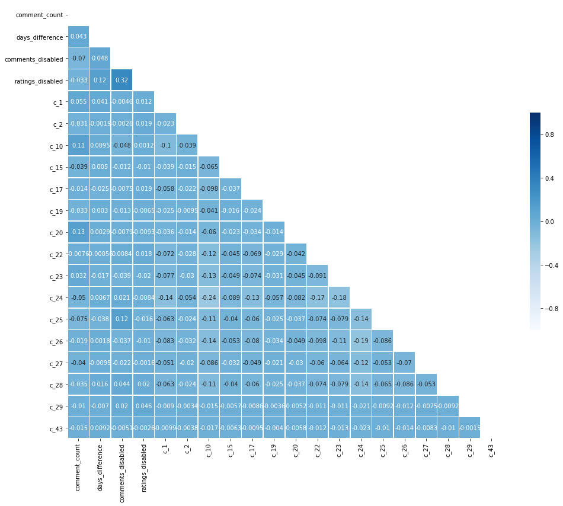

```python
mask = np.zeros_like(corr3, dtype=np.bool)
mask[np.triu_indices_from(mask)] = True

f, ax = plt.subplots(figsize=(16.5, 13.5))

sns.heatmap(corr3, mask=mask, cmap='Blues', vmax=1,vmin=-1,
            center=0,
            square=True, linewidths=.5, cbar_kws={"shrink": .5}, annot=True)
```

- regression model: first use statsmodel to see p values (not available in scikit learn)

```python
X = np.array(X_train, dtype=float)
y = np.array(y_train, dtype=float)

X2 = sm.add_constant(X)
est = sm.OLS(y, X2)
est2 = est.fit()
print(est2.summary())
```

```
                            OLS Regression Results
==============================================================================
Dep. Variable:                      y   R-squared:                       0.211
Model:                            OLS   Adj. R-squared:                  0.210
Method:                 Least Squares   F-statistic:                     374.6
Date:                Mon, 06 Jan 2020   Prob (F-statistic):               0.00
Time:                        20:24:33   Log-Likelihood:                 62154.
No. Observations:               26673   AIC:                        -1.243e+05
Df Residuals:                   26653   BIC:                        -1.241e+05
Df Model:                          19
Covariance Type:            nonrobust
==============================================================================
                 coef    std err          t      P>|t|      [0.025      0.975]
------------------------------------------------------------------------------
const          0.0343      0.000    237.665      0.000       0.034       0.035
x1             0.0052      0.000     35.338      0.000       0.005       0.006
x2            -0.0023      0.000    -16.003      0.000      -0.003      -0.002
x3            -0.0009      0.000     -5.536      0.000      -0.001      -0.001
x4            -0.0014      0.000     -9.239      0.000      -0.002      -0.001
x5            -0.0016      0.000    -12.133      0.000      -0.002      -0.001
x6            -0.0014      0.000     -9.718      0.000      -0.002      -0.001
x7             0.0040      0.000     31.908      0.000       0.004       0.004
x8             0.0002      0.000      1.070      0.285      -0.000       0.000
x9            -0.0043      0.000    -31.400      0.000      -0.005      -0.004
x10           -0.0012      0.000     -8.406      0.000      -0.001      -0.001
x11           -0.0003      0.000     -2.440      0.015      -0.001   -6.82e-05
x12            0.0021      0.000     15.845      0.000       0.002       0.002
x13            0.0025      0.000     18.774      0.000       0.002       0.003
x14           -0.0022      0.000    -19.168      0.000      -0.002      -0.002
x15           -0.0048      0.000    -35.245      0.000      -0.005      -0.005
x16            0.0033      0.000     25.220      0.000       0.003       0.004
x17            0.0010      0.000      7.543      0.000       0.001       0.001
x18           -0.0006      0.000     -4.460      0.000      -0.001      -0.000
x19        -3.972e-05      0.000     -0.276      0.783      -0.000       0.000
x20           -0.0004      0.000     -2.554      0.011      -0.001   -8.55e-05
==============================================================================
Omnibus:                    10019.057   Durbin-Watson:                   2.004
Prob(Omnibus):                  0.000   Jarque-Bera (JB):            51925.102
Skew:                           1.748   Prob(JB):                         0.00
Kurtosis:                       8.873   Cond. No.                     4.91e+15
==============================================================================

Warnings:
[1] Standard Errors assume that the covariance matrix of the errors is correctly specified.
[2] The smallest eigenvalue is 1.58e-27. This might indicate that there are
strong multicollinearity problems or that the design matrix is singular.
```

```python
X_train.columns
```

```
Index(['comment_count', 'days_difference', 'comments_disabled',
       'ratings_disabled', 'c_1', 'c_2', 'c_10', 'c_15', 'c_17', 'c_19',
       'c_20', 'c_22', 'c_23', 'c_24', 'c_25', 'c_26', 'c_27', 'c_28', 'c_29',
       'c_43'],
      dtype='object')
```

- remove variables having p-value greater than 0.05:
  - x8, x19 : c_15, c_29

```python
X = np.array(X_train.drop(['c_15','c_29'],axis=1), dtype=float)
y = np.array(y_train, dtype=float)

X2 = sm.add_constant(X)
est = sm.OLS(y, X2)
est2 = est.fit()
print(est2.summary())
```

```
                            OLS Regression Results
==============================================================================
Dep. Variable:                      y   R-squared:                       0.211
Model:                            OLS   Adj. R-squared:                  0.210
Method:                 Least Squares   F-statistic:                     395.4
Date:                Mon, 06 Jan 2020   Prob (F-statistic):               0.00
Time:                        20:24:33   Log-Likelihood:                 62154.
No. Observations:               26673   AIC:                        -1.243e+05
Df Residuals:                   26654   BIC:                        -1.241e+05
Df Model:                          18
Covariance Type:            nonrobust
==============================================================================
                 coef    std err          t      P>|t|      [0.025      0.975]
------------------------------------------------------------------------------
const          0.0343      0.000    237.668      0.000       0.034       0.035
x1             0.0052      0.000     35.337      0.000       0.005       0.006
x2            -0.0023      0.000    -15.997      0.000      -0.003      -0.002
x3            -0.0009      0.000     -5.540      0.000      -0.001      -0.001
x4            -0.0014      0.000     -9.270      0.000      -0.002      -0.001
x5            -0.0019      0.000     -7.260      0.000      -0.002      -0.001
x6            -0.0015      0.000     -8.796      0.000      -0.002      -0.001
x7             0.0037      0.000     10.476      0.000       0.003       0.004
x8            -0.0045      0.000    -18.041      0.000      -0.005      -0.004
x9            -0.0013      0.000     -7.594      0.000      -0.002      -0.001
x10           -0.0005      0.000     -2.431      0.015      -0.001   -9.12e-05
x11            0.0019      0.000      6.615      0.000       0.001       0.002
x12            0.0022      0.000      7.534      0.000       0.002       0.003
x13           -0.0026      0.000     -6.229      0.000      -0.003      -0.002
x14           -0.0050      0.000    -19.341      0.000      -0.006      -0.005
x15            0.0030      0.000      9.715      0.000       0.002       0.004
x16            0.0009      0.000      3.779      0.000       0.000       0.001
x17           -0.0008      0.000     -3.137      0.002      -0.001      -0.000
x18           -0.0004      0.000     -2.711      0.007      -0.001      -0.000
==============================================================================
Omnibus:                    10017.999   Durbin-Watson:                   2.004
Prob(Omnibus):                  0.000   Jarque-Bera (JB):            51916.297
Skew:                           1.748   Prob(JB):                         0.00
Kurtosis:                       8.873   Cond. No.                         7.07
==============================================================================

Warnings:
[1] Standard Errors assume that the covariance matrix of the errors is correctly specified.
```

- model with scikit learn

```python
reg = LinearRegression().fit(X_train.drop(['c_15','c_29'],axis=1), y_train)
pred_test = reg.predict(X_test.drop(['c_15','c_29'],axis=1))
pred_train = reg.predict(X_train.drop(['c_15','c_29'],axis=1))
```

```python
from sklearn.metrics import r2_score
print('Train R2: ',r2_score(y_train, pred_train))
print('Test R2: ',r2_score(y_test, pred_test))
```

```
Train R2:  0.21073031454162716
Test R2:  0.2249534981268564
```

#### R-square is 22% so we cannot predict like ratio of a video at some definite time after publishment using time since publishment, category id, rating_disables, comments_disabled as input variables. We need more explanatory variables